# IrisIneke.Rmd

Iris Ineke

2024-10-17

## Presentatie (voorbereiden)

(Zondag 13 oktober)

Ik moet voor het plan van aanpak de samples uitzoeken. De verschillende samples:

- Baseline_RNAseq (4)
- NonTreated_RNAseq (6)
- Treated_RNAseq (6)
- NSG_Baseline_000_RNAseq (5)
- NSG_Non-Treatment_000_RNAseq (5)
- NSG_Entinostat_000_RNAseq (5)
- Baseline_TCRseq (6)
- NonTreated_TCRseq (6)
- Treated_TCRseq (6)

Er zijn dus drie groepen:

- RNAseq
- NSG_RNAseq
- TCRseq

en elke groep bestaat uit:

- Baseline
- Non_treated
- Treated

De sample nummers van de TCRseq en de RNAseq zijn allebei in de 400, Dus ik vermoed dat ze twee sequence technieken op dezelfde samples hebben uitgevoerd.

Wat is het verschil tussen de TCRseq, RNAseq en NSG_RNAseq:

- RNAseq: meet de gen-expressie (onder bepaalde omstandigheden)
- TCRseq: meet de reactie van het immuunsysteem (door te kijken naar de hoeveelheid T-celreceptors ( cellen die het antigenen herkennen))
- NSG_RNAseq: NSG-muizen zijn muizen die een zwak immuunsysteem hebben en daardoor gebruikt worden om menselijke cellen in te enten (zonder dat het immuunsysteem van de muis ze afstoot).

Wat is het verschil tussen de Baseline, Non_treated en Treated:

- Baseline is voor de tumor
- Non_treated is na de tumor zonder entinostat
- Treated is na de tumor met entinostat

quality control: welke tools gaan we gebruiken en waarom: - Trimmomatic: om de lage kwaliteit reads van het sequensen eruit te halen. Waarom: Om foutieve conclusies door foutieve data later te voorkomen (als je data gebruikt die niet klopt, trek je uit die data ook conclusies die niet overeenkomen met de werkelijkheid). - Fastqc: geeft een rapport met de kwaliteit van de data. Waarom: Hieruit kun je bepalen wat je eventueel wilt aanpassen met Trimmomatic. - multiqc: voegt alle Fastqc rapporten van samples samen tot een rapport. Waarom: Zo kun je makkelijker de resultaten van Fastqc van alle samples bekijken.

(Maandag 14 oktober)

Alles uitgeschreven voor de presentatie en het plan van aanpak:

Tabel van de samples (van de Transcriptomics):

|  | **Baseline** | **Non_treated** | **Treated** |
| --- | --- | --- | --- |
| **RNAseq** | 4 | 6 | 6 |
| **NSG_RNAseq** | 5 | 5 | 5 |
| **TCRseq** | 6 | 6 | 6 |

**Samples**  
Er zijn voor het transcriptomics gedeelte in totaal 49 samples. Deze samples bestaan uit drie groepen; RNAseq, NSG_RNAseq en TCRseq. En al deze groepen bestaan uit baseline, non_treated en treated. De RNAseq en de TCRseq zijn waarschijnlijk uitgevoerd op dezelfde samples, aangezien de identificatienummers overeenkomen met elkaar. De NSG_RNAseq zijn een andere soort samples. NSG staat in dit geval voor een soort muis die gekweekt wordt en vaak voor onderzoek wordt gebruikt. Het immuunsysteem van deze muis is namelijk zeer zwak of helemaal afwezig. Hierdoor is de NSG-muis perfect om menselijke cellen in te enten, omdat het immuunsysteem van de muis de cellen niet goed kan afbreken. Hierdoor kunnen ze in het onderzoek kijken welk effect de mutatie op menselijke cellen heeft zonder menselijke proefpersonen te hoeven gebruiken. Met de RNA-sequencing wordt er gekeken naar de gen-expressie onder bepaalde omstandigheden. In dit geval dus zonder mutatie (baseline) met mutatie (non_treated) en met mutatie en medicatie (treated). De TCR-sequencing meet de reactie van het immuunsysteem door te kijken naar de hoeveelheid T-celreceptors (cellen die het antigen herkennen).

**quality control**  
We gaan Fastqc en Multiqc gebruiken om te bepalen wat we willen verbeteren aan de data. Dit doen we door middel van het rapport dat uit Multiqc komt (wat een samenvatting maakt van alle rapporten die uit Fastqc komen). Hierna gaan we Trimmomatic gebruiken om de lage kwaliteit reads van het sequensen eruit te halen. Dit doen we om foutieve conclusies door foutieve data later te voorkomen. Als je data gebruikt die niet klopt, trek je immers (uit die data) ook conclusies die niet overeenkomen met de werkelijkheid. Hierna voeren we nog een keer Fastqc en Multiqc uit om te kijken of Trimmomatic voldoende verbeterd heeft. Als er uit dit rapport blijkt dat de data nog niet genoeg is opgeschoond zullen we nog een keer Trimmomatic moeten gebruiken totdat we tevreden zijn.

**BELANGRIJK:**  
Later erachter gekomen dat ze in de NSG-muizen toch geen menselijke cellen hebben gestopt. Ze hebben enkel een slechter immuunsysteem.

## Quality control:

(woensdag 16 oktober) FastQC en MultiQC uitgevoerd op de data (duurt erg lang, rekening mee houden in planning).

Uit het Multiqc rapport blijkt dat ‘Per Base Sequence Content’, ‘Per Sequence GC Content’ en ‘Sequence Duplication Levels’ verbeterd kunnen worden.

Trimmomatic uitgevoerd (instellingen zijn op basis van Multiqc ‘Sequence Quality Histograms’ plot):

```bash
cat /students/2024-2025/Thema05/BlaasKanker/Transcriptomics/SRR_Acc_List.txt | \
  parallel 'TrimmomaticPE -threads 8 ' \
                  '/students/2024-2025/Thema05/BlaasKanker/Transcriptomics/output/fastq/{}_1.fastq' \
                  '/students/2024-2025/Thema05/BlaasKanker/Transcriptomics/output/fastq/{}_2.fastq' \
                  '/students/2024-2025/Thema05/BlaasKanker/Transcriptomics/output/quality_control/trimmomatic2/{}_paired.1.fastq ' \
                  '/students/2024-2025/Thema05/BlaasKanker/Transcriptomics/output/quality_control/trimmomatic2/{}_unpaired.1.fastq ' \
                  '/students/2024-2025/Thema05/BlaasKanker/Transcriptomics/output/quality_control/trimmomatic2/{}_paired.2.fastq ' \
                  '/students/2024-2025/Thema05/BlaasKanker/Transcriptomics/output/quality_control/trimmomatic2/{}_unpaired.2.fastq ' \
                  'ILLUMINACLIP:/students/2024-2025/Thema05/BlaasKanker/tools/trim_adapters/TruSeq3-PE.fa:2:30:10 ' \
                  'LEADING:30' \
                  'TRAILING:25'
```

Weer Fastqc en Multiqc gerund. De unpaired moeten niet worden meegenomen in de analyse (dit zorgde namelijk voor een erg chaotisch Multiqc rapport). En threads meegeven, zodat het niet 3 uur duurt.

```bash
fastqc /students/2024-2025/Thema05/BlaasKanker/Transcriptomics/output/quality_control/trimmomatic2/*_paired.*  \
  -o /students/2024-2025/Thema05/BlaasKanker/Transcriptomics/output/quality_control/fastqc_after_trim2.2 -t 12
```

Trimmomatic met andere (strengere) settings gerund na overleg met de groep:

```bash
cat /students/2024-2025/Thema05/BlaasKanker/Transcriptomics/SRR_Acc_List.txt | \
  parallel 'TrimmomaticPE -threads 10 ' \
                  '/students/2024-2025/Thema05/BlaasKanker/Transcriptomics/output/fastq/{}_1.fastq' \
                  '/students/2024-2025/Thema05/BlaasKanker/Transcriptomics/output/fastq/{}_2.fastq' \
                  '/students/2024-2025/Thema05/BlaasKanker/Transcriptomics/output/quality_control/trimmomatic3/{}_paired.1.fastq ' \
                  '/students/2024-2025/Thema05/BlaasKanker/Transcriptomics/output/quality_control/trimmomatic3/{}_unpaired.1.fastq ' \
                  '/students/2024-2025/Thema05/BlaasKanker/Transcriptomics/output/quality_control/trimmomatic3/{}_paired.2.fastq ' \
                  '/students/2024-2025/Thema05/BlaasKanker/Transcriptomics/output/quality_control/trimmomatic3/{}_unpaired.2.fastq ' \
                  'ILLUMINACLIP:/students/2024-2025/Thema05/BlaasKanker/tools/trim_adapters/TruSeq3-PE.fa:2:30:10 ' \
                  'LEADING:32' \
                  'TRAILING:30'
```

```bash
ls /students/2024-2025/Thema05/BlaasKanker/Transcriptomics/output/quality_control/trimmomatic3 | grep -i -E "*_paired*" | \
parallel "/students/2024-2025/Thema05/BlaasKanker/Transcriptomics/tools/bin/falco /students/2024-2025/Thema05/BlaasKanker/Transcriptomics/output/quality_control/trimmomatic3/{} -o /students/2024-2025/Thema05/BlaasKanker/Transcriptomics/output/quality_control/fastqc_after_trim3/{}_fastqc_report"
```

Daar weer Multiqc op gedaan.

```bash
multiqc /students/2024-2025/Thema05/BlaasKanker/Transcriptomics/output/quality_control/fastqc_after_trim3/* \
-o /students/2024-2025/Thema05/BlaasKanker/Transcriptomics/output/quality_control/multiqc_after_trim3
```

De adapter content is erg hoog. Deze proberen te verminderen met headcrop (begin eraf halen).

```bash
cat /students/2024-2025/Thema05/BlaasKanker/Transcriptomics/SRR_Acc_List.txt | \
  parallel 'TrimmomaticPE -threads 10 ' \
                  '/students/2024-2025/Thema05/BlaasKanker/Transcriptomics/output/fastq/{}_1.fastq' \
                  '/students/2024-2025/Thema05/BlaasKanker/Transcriptomics/output/fastq/{}_2.fastq' \
                  '/students/2024-2025/Thema05/BlaasKanker/Transcriptomics/output/quality_control/trimmomatic3/{}_paired.1.fastq ' \
                  '/students/2024-2025/Thema05/BlaasKanker/Transcriptomics/output/quality_control/trimmomatic3/{}_unpaired.1.fastq ' \
                  '/students/2024-2025/Thema05/BlaasKanker/Transcriptomics/output/quality_control/trimmomatic3/{}_paired.2.fastq ' \
                  '/students/2024-2025/Thema05/BlaasKanker/Transcriptomics/output/quality_control/trimmomatic3/{}_unpaired.2.fastq ' \
                  'ILLUMINACLIP:/students/2024-2025/Thema05/BlaasKanker/tools/trim_adapters/TruSeq3-PE.fa:2:30:10 ' \
                  'HEADCROP:7' \
                  'LEADING:32' \
                  'TRAILING:30'
```

Na advies van Marcel te hebben gevraagd over het aantal adapter content die we hebben tot de conclusie gekomen dat we waarschijnlijk [geen Trimmomatic](https://pubmed.ncbi.nlm.nih.gov/33575617/) hoeven te gebruiken (data is al goed genoeg).

## Mapping

We zijn erachter gekomen dat in de NSG muizen geen menselijke cellen zitten. Dus deze moeten we ook mappen tegen het muis-referentie-genoom (Wat wel heel gek is is dat in het artikel staat dat ze alles tegen het menselijke-referentie-genoom hebben gemapt, is dit een fout ?).  
Code van [Ramon](https://github.com/RamonReilman/GenomicsTranscriptomics/blob/main/Transcriptomics/logbooks/RamonReilman.Rmd)

```bash
gffread -E /students/2024-2025/Thema05/BlaasKanker/Transcriptomics/tools/ref_genes/ncbi_dataset/data/GCF_000001405.40/genomic.gff -T -o  /students/2024-2025/Thema05/BlaasKanker/Transcriptomics/tools/ref_genes/ncbi_dataset/data/GCF_000001405.40/genomic.gtf
```

```bash
STAR --runThreadN 4 --runMode genomeGenerate --genomeDir /students/2024-2025/Thema05/BlaasKanker/Transcriptomics/tools/star/index_GRCh38 --genomeFastaFiles /students/2024-2025/Thema05/BlaasKanker/Transcriptomics/tools/ref_genes/ncbi_dataset/data/GCF_000001405.40/GCF_000001405.40_GRCh38.p14_genomic.fna --sjdbGTFfile /students/2024-2025/Thema05/BlaasKanker/Transcriptomics/tools/ref_genes/ncbi_dataset/data/GCF_000001405.40/genomic.gtf --sjdbOverhang 75
```

```bash
cat /students/2024-2025/Thema05/BlaasKanker/Transcriptomics/nsg_mouse_SRR.txt | \
    parallel 'STAR --runThreadN 6 ' \
        '--genomeDir /students/2024-2025/Thema05/BlaasKanker/Transcriptomics/tools/star/index_GRCh38/ ' \
        '--readFilesIn /students/2024-2025/Thema05/BlaasKanker/Transcriptomics/output/fastq/{}_1.fastq /students/2024-2025/Thema05/BlaasKanker/Transcriptomics/output/fastq/{}_2.fastq ' \
        '--outSAMtype BAM SortedByCoordinate ' \
        '--quantMode GeneCounts ' \
        '--genomeLoad LoadAndRemove' \
        '--limitBAMsortRAM 2000000000 ' \
        '--outFileNamePrefix /students/2024-2025/Thema05/BlaasKanker/Transcriptomics/output/mapping/{}_star_'
```

```bash
cat /students/2024-2025/Thema05/BlaasKanker/Transcriptomics/nsg_mouse_SRR.txt | \
    parallel 'STAR --runThreadN 6 ' \
        '--genomeDir /students/2024-2025/Thema05/BlaasKanker/Transcriptomics/tools/star/index_GRCm39/ ' \
        '--readFilesIn /students/2024-2025/Thema05/BlaasKanker/Transcriptomics/output/fastq/{}_1.fastq /students/2024-2025/Thema05/BlaasKanker/Transcriptomics/output/fastq/{}_2.fastq ' \
        '--outSAMtype BAM SortedByCoordinate ' \
        '--quantMode GeneCounts ' \
        '--genomeLoad LoadAndRemove' \
        '--limitBAMsortRAM 2000000000 ' \
        '--outFileNamePrefix /students/2024-2025/Thema05/BlaasKanker/Transcriptomics/output/mapping/{}_mm39_star_'
```

De mapping tegen het muis genoom ziet er beter uit, dus waarschijnlijk zit er een fout in het artikel.

## Deseq

(30/31 oktober) De volgende code is van [Ramon](https://github.com/RamonReilman/GenomicsTranscriptomics/blob/main/Transcriptomics/logbooks/RamonReilman.Rmd) (Zie ook Teams):

```r
file.names <- list.files('/students/2024-2025/Thema05/BlaasKanker/Transcriptomics/output/mapping/',
                         pattern = '*_star_ReadsPerGene.out.tab')

## Function for reading in files
read_sample <- function(file.name) {
  ## Extract the sample name for naming the column (retaining the 'SRR....' part)
  sample.name <- strsplit(file.name, ".", fixed = TRUE)[[1]][1]
  sample <- read.table(file.name, header = FALSE, sep="\t",
                       row.names = NULL, skip = 4)
  ## Rename the count column
  names(sample)[2] <- sample.name
  ## Return a subset containing the transcript ID and sample name columns
  return(sample[c(1, 2)])
}
```

```r
setwd('/students/2024-2025/Thema05/BlaasKanker/Transcriptomics/output/mapping/')

## Read the FIRST sample
counts <- read_sample(file.names[1])

## Read the remaining files and merge the contents
for (file.name in file.names[2:length(file.names)]) {
  sample <- read_sample(file.name)
  counts <- merge(counts, sample, by = 1)
}

# Set the row names to the transcript IDs
rownames(counts) <- counts$V1
counts <- counts[-1]
head(counts)
```

```
##                    SRR12129014_star_ReadsPerGene SRR12129015_star_ReadsPerGene
## MissingGeneID                               5859                          4387
## gene-0610005C13Rik                             3                             0
## gene-0610006L08Rik                             0                             1
## gene-0610009E02Rik                             0                             1
## gene-0610009L18Rik                            53                            29
## gene-0610010K14Rik                          1024                           790
##                    SRR12129016_star_ReadsPerGene SRR12129017_star_ReadsPerGene
## MissingGeneID                               7820                          8707
## gene-0610005C13Rik                             0                             0
## gene-0610006L08Rik                             0                             0
## gene-0610009E02Rik                             1                             1
## gene-0610009L18Rik                            25                            93
## gene-0610010K14Rik                           881                          1408
##                    SRR12129018_star_ReadsPerGene SRR12129019_star_ReadsPerGene
## MissingGeneID                               3405                          3821
## gene-0610005C13Rik                             0                             0
## gene-0610006L08Rik                             0                             2
## gene-0610009E02Rik                             0                             1
## gene-0610009L18Rik                            43                            34
## gene-0610010K14Rik                           897                           523
##                    SRR12129020_star_ReadsPerGene SRR12129021_star_ReadsPerGene
## MissingGeneID                               3777                          6823
## gene-0610005C13Rik                             1                             0
## gene-0610006L08Rik                             0                             0
## gene-0610009E02Rik                             1                             4
## gene-0610009L18Rik                            44                            93
## gene-0610010K14Rik                           492                          1304
##                    SRR12129022_star_ReadsPerGene SRR12129023_star_ReadsPerGene
## MissingGeneID                               4673                          7162
## gene-0610005C13Rik                             0                             0
## gene-0610006L08Rik                             0                             0
## gene-0610009E02Rik                             0                             0
## gene-0610009L18Rik                            25                            55
## gene-0610010K14Rik                           975                          1390
##                    SRR12129024_star_ReadsPerGene SRR12129025_star_ReadsPerGene
## MissingGeneID                               2160                          5096
## gene-0610005C13Rik                             1                             0
## gene-0610006L08Rik                             1                             0
## gene-0610009E02Rik                             1                             0
```

[output cut: 57 more lines]

```
## gene-0610010K14Rik                           735                          1145
##                    SRR12129042_star_ReadsPerGene SRR12129043_star_ReadsPerGene
## MissingGeneID                               8495                          8854
## gene-0610005C13Rik                             2                             4
## gene-0610006L08Rik                             0                             0
## gene-0610009E02Rik                             5                             8
## gene-0610009L18Rik                           122                           150
## gene-0610010K14Rik                          1618                          1689
##                    SRR12129044_star_ReadsPerGene
## MissingGeneID                               7730
## gene-0610005C13Rik                             2
## gene-0610006L08Rik                             1
## gene-0610009E02Rik                             4
## gene-0610009L18Rik                           160
## gene-0610010K14Rik                          1511
```

```r
col_data <- read.csv("/students/2024-2025/Thema05/BlaasKanker/etc/DSEQ_verwerking(Sheet1).csv", sep = ";")
rownames(col_data) <- col_data[,1]
col_data
```

```
##                                                         Run
## SRR12129014_star_ReadsPerGene SRR12129014_star_ReadsPerGene
## SRR12129015_star_ReadsPerGene SRR12129015_star_ReadsPerGene
## SRR12129016_star_ReadsPerGene SRR12129016_star_ReadsPerGene
## SRR12129017_star_ReadsPerGene SRR12129017_star_ReadsPerGene
## SRR12129018_star_ReadsPerGene SRR12129018_star_ReadsPerGene
## SRR12129019_star_ReadsPerGene SRR12129019_star_ReadsPerGene
## SRR12129020_star_ReadsPerGene SRR12129020_star_ReadsPerGene
## SRR12129021_star_ReadsPerGene SRR12129021_star_ReadsPerGene
## SRR12129022_star_ReadsPerGene SRR12129022_star_ReadsPerGene
## SRR12129023_star_ReadsPerGene SRR12129023_star_ReadsPerGene
## SRR12129024_star_ReadsPerGene SRR12129024_star_ReadsPerGene
## SRR12129025_star_ReadsPerGene SRR12129025_star_ReadsPerGene
## SRR12129026_star_ReadsPerGene SRR12129026_star_ReadsPerGene
## SRR12129027_star_ReadsPerGene SRR12129027_star_ReadsPerGene
## SRR12129028_star_ReadsPerGene SRR12129028_star_ReadsPerGene
## SRR12129029_star_ReadsPerGene SRR12129029_star_ReadsPerGene
## SRR12129030_star_ReadsPerGene SRR12129030_star_ReadsPerGene
## SRR12129031_star_ReadsPerGene SRR12129031_star_ReadsPerGene
## SRR12129032_star_ReadsPerGene SRR12129032_star_ReadsPerGene
## SRR12129033_star_ReadsPerGene SRR12129033_star_ReadsPerGene
## SRR12129034_star_ReadsPerGene SRR12129034_star_ReadsPerGene
## SRR12129035_star_ReadsPerGene SRR12129035_star_ReadsPerGene
## SRR12129036_star_ReadsPerGene SRR12129036_star_ReadsPerGene
## SRR12129037_star_ReadsPerGene SRR12129037_star_ReadsPerGene
## SRR12129038_star_ReadsPerGene SRR12129038_star_ReadsPerGene
## SRR12129039_star_ReadsPerGene SRR12129039_star_ReadsPerGene
## SRR12129040_star_ReadsPerGene SRR12129040_star_ReadsPerGene
## SRR12129041_star_ReadsPerGene SRR12129041_star_ReadsPerGene
## SRR12129042_star_ReadsPerGene SRR12129042_star_ReadsPerGene
## SRR12129043_star_ReadsPerGene SRR12129043_star_ReadsPerGene
## SRR12129044_star_ReadsPerGene SRR12129044_star_ReadsPerGene
##                                                    source_name  strain
## SRR12129014_star_ReadsPerGene    C57BL/6_bladder tumor_Vehicle C57BL/6
## SRR12129015_star_ReadsPerGene C57BL/6_bladder tumor_Entinostat C57BL/6
## SRR12129016_star_ReadsPerGene    C57BL/6_bladder tumor_Vehicle C57BL/6
## SRR12129017_star_ReadsPerGene    C57BL/6_bladder tumor_Vehicle C57BL/6
## SRR12129018_star_ReadsPerGene    C57BL/6_bladder tumor_Vehicle C57BL/6
## SRR12129019_star_ReadsPerGene C57BL/6_bladder tumor_Entinostat C57BL/6
## SRR12129020_star_ReadsPerGene C57BL/6_bladder tumor_Entinostat C57BL/6
```

[output cut: 41 more lines]

```
## SRR12129030_star_ReadsPerGene   Baseline
## SRR12129031_star_ReadsPerGene   Baseline
## SRR12129032_star_ReadsPerGene   Baseline
## SRR12129033_star_ReadsPerGene   Baseline
## SRR12129034_star_ReadsPerGene   Baseline
## SRR12129035_star_ReadsPerGene Entinostat
## SRR12129036_star_ReadsPerGene Entinostat
## SRR12129037_star_ReadsPerGene Entinostat
## SRR12129038_star_ReadsPerGene Entinostat
## SRR12129039_star_ReadsPerGene Entinostat
## SRR12129040_star_ReadsPerGene    Vehicle
## SRR12129041_star_ReadsPerGene    Vehicle
## SRR12129042_star_ReadsPerGene    Vehicle
## SRR12129043_star_ReadsPerGene    Vehicle
## SRR12129044_star_ReadsPerGene    Vehicle
```

## Annot count_data

Het annoteren van onze data zorgt ervoor dat de genen de NCBI naamgeving krijgen. Zo is het straks overzichtelijker om informatie te vinden over de genen.

```r
library(dplyr)
library(tidyr)

col_data <- col_data %>%
    dplyr::group_by(strain, treatment) %>%
    dplyr::mutate(r_num = row_number()) %>%
    dplyr::ungroup() %>%
    mutate(condition = paste0(strain, "_", treatment, "_r", r_num))
head(col_data)
```

```
## # A tibble: 6 × 6
##   Run                           source_name     strain treatment r_num condition
##   <chr>                         <chr>           <chr>  <chr>     <int> <chr>
## 1 SRR12129014_star_ReadsPerGene C57BL/6_bladde… C57BL… Vehicle       1 C57BL/6_…
## 2 SRR12129015_star_ReadsPerGene C57BL/6_bladde… C57BL… Entinost…     1 C57BL/6_…
## 3 SRR12129016_star_ReadsPerGene C57BL/6_bladde… C57BL… Vehicle       2 C57BL/6_…
## 4 SRR12129017_star_ReadsPerGene C57BL/6_bladde… C57BL… Vehicle       3 C57BL/6_…
## 5 SRR12129018_star_ReadsPerGene C57BL/6_bladde… C57BL… Vehicle       4 C57BL/6_…
## 6 SRR12129019_star_ReadsPerGene C57BL/6_bladde… C57BL… Entinost…     2 C57BL/6_…
```

In de bestanden kon niks gevonden worden over de genen, maar zo is het wel duidelijker waar elke kolom voor staat. Dat moet nu nog toegepast worden in de counts df

```r
for (i in 1:nrow(col_data)) {
  idx <- grep(col_data$Run[i], names(counts))
  names(counts)[idx] <- col_data$condition[i]
}
head(counts)
```

```
##                    C57BL/6_Vehicle_r1 C57BL/6_Entinostat_r1 C57BL/6_Vehicle_r2
## MissingGeneID                    5859                  4387               7820
## gene-0610005C13Rik                  3                     0                  0
## gene-0610006L08Rik                  0                     1                  0
## gene-0610009E02Rik                  0                     1                  1
## gene-0610009L18Rik                 53                    29                 25
## gene-0610010K14Rik               1024                   790                881
##                    C57BL/6_Vehicle_r3 C57BL/6_Vehicle_r4 C57BL/6_Entinostat_r2
## MissingGeneID                    8707               3405                  3821
## gene-0610005C13Rik                  0                  0                     0
## gene-0610006L08Rik                  0                  0                     2
## gene-0610009E02Rik                  1                  0                     1
## gene-0610009L18Rik                 93                 43                    34
## gene-0610010K14Rik               1408                897                   523
##                    C57BL/6_Entinostat_r3 C57BL/6_Vehicle_r5 C57BL/6_Baseline_r1
## MissingGeneID                       3777               6823                4673
## gene-0610005C13Rik                     1                  0                   0
## gene-0610006L08Rik                     0                  0                   0
## gene-0610009E02Rik                     1                  4                   0
## gene-0610009L18Rik                    44                 93                  25
## gene-0610010K14Rik                   492               1304                 975
##                    C57BL/6_Baseline_r2 C57BL/6_Entinostat_r4
## MissingGeneID                     7162                  2160
## gene-0610005C13Rik                   0                     1
## gene-0610006L08Rik                   0                     1
## gene-0610009E02Rik                   0                     1
## gene-0610009L18Rik                  55                    15
## gene-0610010K14Rik                1390                   419
##                    C57BL/6_Baseline_r3 C57BL/6_Entinostat_r5
## MissingGeneID                     5096                  2718
## gene-0610005C13Rik                   0                     0
## gene-0610006L08Rik                   0                     0
## gene-0610009E02Rik                   0                     4
## gene-0610009L18Rik                  24                    49
## gene-0610010K14Rik                 972                   676
##                    C57BL/6_Entinostat_r6 C57BL/6_Vehicle_r6 C57BL/6_Baseline_r4
## MissingGeneID                       3870               9562                5163
## gene-0610005C13Rik                     0                  0                   0
## gene-0610006L08Rik                     0                  0                   0
## gene-0610009E02Rik                     6                  0                   2
```

[output cut: 22 more lines]

```
## gene-0610010K14Rik              1528              1339               387
##                    NSG_Entinostat_r5 NSG_Vehicle_r1 NSG_Vehicle_r2
## MissingGeneID                  12470           5393           7122
## gene-0610005C13Rik                 2              2              1
## gene-0610006L08Rik                 1              0              0
## gene-0610009E02Rik                13              6             11
## gene-0610009L18Rik               113             41             50
## gene-0610010K14Rik              1393            735           1145
##                    NSG_Vehicle_r3 NSG_Vehicle_r4 NSG_Vehicle_r5
## MissingGeneID                8495           8854           7730
## gene-0610005C13Rik              2              4              2
## gene-0610006L08Rik              0              0              1
## gene-0610009E02Rik              5              8              4
## gene-0610009L18Rik            122            150            160
## gene-0610010K14Rik           1618           1689           1511
```

Nu zijn de SRR* namen vervangen met waar ze voor staan en is de df duidelijker te lezen, om straks makkelijker de kolommen op te halen die horen bij elk mogelijke variant groepeer ik deze.

```r
print(colnames(counts))
```

```
##  [1] "C57BL/6_Vehicle_r1"    "C57BL/6_Entinostat_r1" "C57BL/6_Vehicle_r2"
##  [4] "C57BL/6_Vehicle_r3"    "C57BL/6_Vehicle_r4"    "C57BL/6_Entinostat_r2"
##  [7] "C57BL/6_Entinostat_r3" "C57BL/6_Vehicle_r5"    "C57BL/6_Baseline_r1"
## [10] "C57BL/6_Baseline_r2"   "C57BL/6_Entinostat_r4" "C57BL/6_Baseline_r3"
## [13] "C57BL/6_Entinostat_r5" "C57BL/6_Entinostat_r6" "C57BL/6_Vehicle_r6"
## [16] "C57BL/6_Baseline_r4"   "NSG_Baseline_r1"       "NSG_Baseline_r2"
## [19] "NSG_Baseline_r3"       "NSG_Baseline_r4"       "NSG_Baseline_r5"
## [22] "NSG_Entinostat_r1"     "NSG_Entinostat_r2"     "NSG_Entinostat_r3"
## [25] "NSG_Entinostat_r4"     "NSG_Entinostat_r5"     "NSG_Vehicle_r1"
## [28] "NSG_Vehicle_r2"        "NSG_Vehicle_r3"        "NSG_Vehicle_r4"
## [31] "NSG_Vehicle_r5"
```

```r
C57BL_Vehicle <- grep("C57BL/6_Vehicle", names(counts))
C57BL_Entinostat <- grep("C57BL/6_Entinostat", names(counts))
C57BL_Baseline <- grep("C57BL/6_Baseline", names(counts))

nsg_Vehicle <- grep("NSG_Vehicle", names(counts))
nsg_Entinostat <- grep("NSG_Entinostat", names(counts))
nsg_Baseline <- grep("NSG_Baseline", names(counts))
```

Nu kunnen deze variabelen gebruikt worden om de juiste kolommen te selecteren.

Dan kan dit nu samengevoegd worden met DESEQ, wat Janine heeft uitgezocht. Bekijk [Janine haar logboek](https://github.com/RamonReilman/GenomicsTranscriptomics/blob/main/Transcriptomics/logbooks/JaninePostmus.Rmd) voor meer informatie over de code.

```r
library(DESeq2)
# Making deseqdataset with counts en coldata
dds <- DESeqDataSetFromMatrix(countData = counts,
                              colData = col_data,
                              design = ~ 0 + source_name)
```

```
##   Note: levels of factors in the design contain characters other than
##   letters, numbers, '_' and '.'. It is recommended (but not required) to use
##   only letters, numbers, and delimiters '_' or '.', as these are safe characters
##   for column names in R. [This is a message, not a warning or an error]
```

```r
head(dds)
```

```
## class: DESeqDataSet
## dim: 6 31
## metadata(1): version
## assays(1): counts
## rownames(6): MissingGeneID gene-0610005C13Rik ... gene-0610009L18Rik
##   gene-0610010K14Rik
## rowData names(0):
## colnames(31): C57BL/6_Vehicle_r1 C57BL/6_Entinostat_r1 ...
##   NSG_Vehicle_r4 NSG_Vehicle_r5
## colData names(6): Run source_name ... r_num condition
```

```r
# Prefiltering on low gene counts
keep <- rowSums(counts(dds)) >= 10
ddst <- dds[keep,]
```

```r
# Setting factor level
#dds$treatment <- relevel(dds$treatment, ref = "Baseline")

dds$treatment <- factor(dds$treatment, levels = c("Baseline","Entinostat", "Vehicle"), )
```

```r
# Running deseq
dds <- DESeq(dds)
```

```
##   Note: levels of factors in the design contain characters other than
##   letters, numbers, '_' and '.'. It is recommended (but not required) to use
##   only letters, numbers, and delimiters '_' or '.', as these are safe characters
##   for column names in R. [This is a message, not a warning or an error]
```

[output not shown]

[output not shown]

```r
res <- results(dds)
```

## MA plot

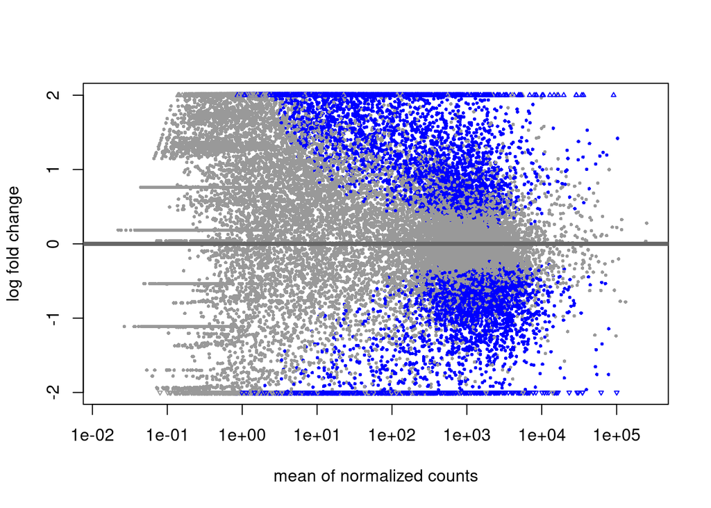

```r
# ylim zijn de limieten van de y-as
plotMA(res, ylim=c(-2,2))
```

De plot bevat nog noise, dus we gaan de ‘Log fold change shrinkage for visualization and ranking’ uitvoeren van de tutorial.

```r
resultsNames(dds)
```

```
## [1] "source_nameC57BL.6_bladder.tumor_Baseline"
## [2] "source_nameC57BL.6_bladder.tumor_Entinostat"
## [3] "source_nameC57BL.6_bladder.tumor_Vehicle"
## [4] "source_nameNSG_bladder.tumor_Baseline"
## [5] "source_nameNSG_bladder.tumor_Entinostat"
## [6] "source_nameNSG_bladder.tumor_Vehicle"
```

```r
resLFC_Baseline <- lfcShrink(dds, coef="source_nameNSG_bladder.tumor_Baseline", type="apeglm")
resLFC_Baseline
```

Bij coef wordt maar 1 input geaccepteerd, dus eerst de twee namen apart invullen van de situaties die we willen visualiseren:

Maar nu is de vraag hoe we dit samen moeten voegen ? Er een vector van maken werkt niet.

[Ramon](https://github.com/RamonReilman/GenomicsTranscriptomics/blob/main/Transcriptomics/logbooks/RamonReilman.Rmd) heeft een subset gemaakt gemaakt van de twee situaties, dit is handig om alleen de informatie van de situaties weer te geven in de plot:

```r
dds_subset <- dds[, dds$source_name %in% c("NSG_bladder tumor_Baseline", "NSG_bladder tumor_Entinostat")]

# re-run DEseq on the subset data
dds_subset <- DESeqDataSet(dds_subset, design = ~ 0 + source_name)
```

```
## factor levels were dropped which had no samples
```

```
##   Note: levels of factors in the design contain characters other than
##   letters, numbers, '_' and '.'. It is recommended (but not required) to use
##   only letters, numbers, and delimiters '_' or '.', as these are safe characters
##   for column names in R. [This is a message, not a warning or an error]
```

```r
dds_subset <- DESeq(dds_subset)
```

```
## found already estimated dispersions, replacing these
```

```
## found already estimated gene-wise dispersions, removing these
```

```
##   Note: levels of factors in the design contain characters other than
##   letters, numbers, '_' and '.'. It is recommended (but not required) to use
##   only letters, numbers, and delimiters '_' or '.', as these are safe characters
##   for column names in R. [This is a message, not a warning or an error]
```

```
## found already estimated dispersions, removing these
```

```
##   Note: levels of factors in the design contain characters other than
##   letters, numbers, '_' and '.'. It is recommended (but not required) to use
##   only letters, numbers, and delimiters '_' or '.', as these are safe characters
##   for column names in R. [This is a message, not a warning or an error]
```

```r
res_subset <- results(dds_subset)
```

Hiermee doorgaan: Plot van alleen de baseline en Entinostat:

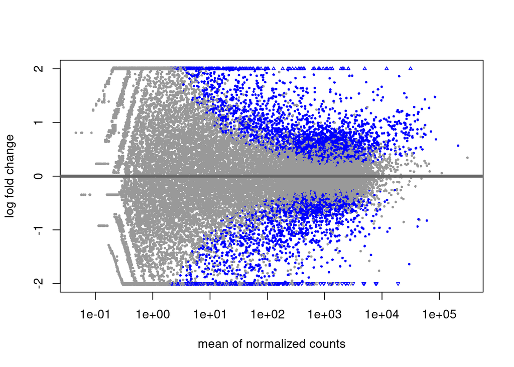

```r
# omdat 2 in log-termen hoog is daar de limit zetten
plotMA(res_subset, ylim=c(-2,2))
```

Interpretatie plot: x-as is de counts en de y-as is de log verandering.  
Dus hoe verder op de x-as hoe meer counts van het gen is. En hoe verder op y-as hoe meer verschillend de expressie van het gen is.  
De genen die significant verschillen in expressie zullen dus de blauwe bolletjes zijn aan de rechterkant van de plot.

[Ramon](https://github.com/RamonReilman/GenomicsTranscriptomics/blob/main/Transcriptomics/logbooks/RamonReilman.Rmd) heeft het probleem met de enkele input van lfcShrink opgelost:

```r
dds_nsg_subset <- dds[, c(nsg_Baseline,nsg_Entinostat)]

dds_nsg_subset <- DESeqDataSet(dds_nsg_subset, design = ~ treatment)
```

```
## factor levels were dropped which had no samples
```

```r
dds_nsg_subset$treatment <- relevel(dds_nsg_subset$treatment, ref = "Baseline")
dds_nsg_subset <- DESeq(dds_nsg_subset)
```

```
## found already estimated dispersions, replacing these
```

```
## found already estimated gene-wise dispersions, removing these
```

```
## found already estimated dispersions, removing these
```

```r
nsg_res <- results(dds_nsg_subset)
```

```r
resultsNames(dds_nsg_subset)
```

```
## [1] "Intercept"                        "treatment_Entinostat_vs_Baseline"
```

Dit lost het probleem op dat uit de resultsNames() eerder alle situaties apart kwamen. Nu zijn ze verdeeld in de situaties die wij wel willen gebruiken (treatment_Entinostat_vs_Baseline) en die wij niet willen gebruiken (Intercept) voor deze plot.  
Hierop kunnen we de lfcShrink wel goed uitvoeren:

```r
resLFC_subset <- lfcShrink(dds_nsg_subset, coef="treatment_Entinostat_vs_Baseline", type="apeglm")
```

```
## using 'apeglm' for LFC shrinkage. If used in published research, please cite:
##     Zhu, A., Ibrahim, J.G., Love, M.I. (2018) Heavy-tailed prior distributions for
##     sequence count data: removing the noise and preserving large differences.
##     Bioinformatics. https://doi.org/10.1093/bioinformatics/bty895
```

```r
resLFC_subset
```

```
## log2 fold change (MAP): treatment Entinostat vs Baseline
## Wald test p-value: treatment Entinostat vs Baseline
## DataFrame with 41641 rows and 5 columns
##                       baseMean log2FoldChange     lfcSE      pvalue        padj
##                      <numeric>      <numeric> <numeric>   <numeric>   <numeric>
## MissingGeneID      5604.453264     0.21152003  0.142318 8.34332e-02 2.28338e-01
## gene-0610005C13Rik    1.355654    -0.00192000  0.273925 9.79082e-01          NA
## gene-0610006L08Rik    0.124862    -0.00296566  0.283677 9.41817e-01          NA
## gene-0610009E02Rik    4.200625    -0.06076901  0.264815 5.88300e-01 7.44126e-01
## gene-0610009L18Rik   58.981930     1.48453315  0.326603 2.66659e-07 2.84434e-05
## ...                        ...            ...       ...         ...         ...
## rna-NR_162810.1              0             NA        NA          NA          NA
## rna-NR_162811.1              0             NA        NA          NA          NA
## rna-NR_162812.1              0             NA        NA          NA          NA
## rna-NR_162813.1              0             NA        NA          NA          NA
## rna-NR_162814.1              0             NA        NA          NA          NA
```

Dan kan nu de plot opnieuw gemaakt worden van de lfcSchrink subset:

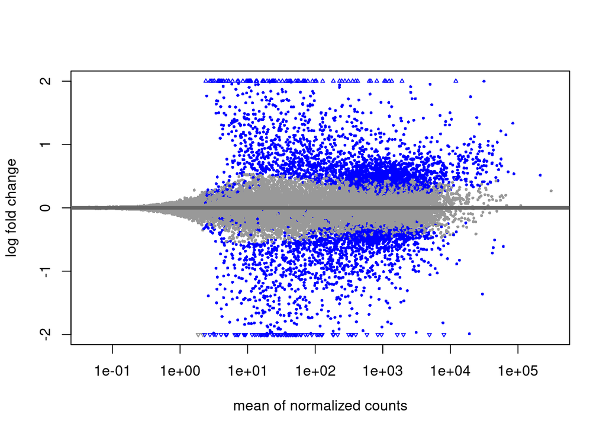

```r
# omdat 2 in log-termen hoog is daar de limit zetten
plotMA(resLFC_subset, ylim=c(-2,2))
```

Dit is echt veel beter. Het is interessant om te kijken welke genen bij welke punten horen, dus we gaan proberen om de genen erbij te zetten. Hiervoor is een [online artikel](https://www.r-bloggers.com/2016/01/repel-overlapping-text-labels-in-ggplot2/) gebruikt. Eerst de plot in ggplot maken:

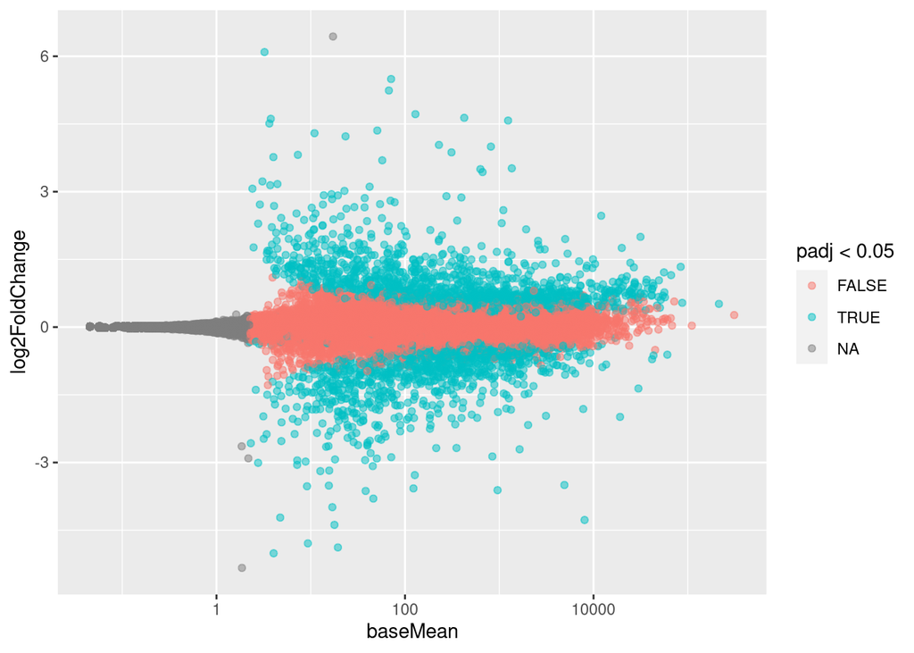

```r
#help("plotMA")

library(ggplot2)
library(ggrepel)

# data frame maken van resLFC_subset
ressub_df <- as.data.frame(resLFC_subset)

# voegt nieuwe kolom toe aan df met de genen
# (de rownames zijn dus blijkbaar de genen, dus deze neemt hij)
ressub_df$gene <- rownames(ressub_df)

# MAplot met ggplot2 maken:
# x=baseMean : gemiddelde expressie op x-as
# y=log2FoldChange " expressie log-2 verandering op de y-as
ggplot(ressub_df, aes(x=baseMean, y=log2FoldChange)) +
    # geom_point voegt punten toe aan de plot
    # color = padj < 0.05 : kleurt alle punten met p-waarde hoger dan 0.05
    # alpha=0.5 : zorgt ervoor dat de punten doorzichtig zijn (beter af te lezen bij overlap)
    geom_point(aes(color = padj < 0.05), alpha=0.5) +
    # scale_x_log10() : zorgt ervoor dat de as naar log aangepast wordt (zoals de input data)
    scale_x_log10()
```

Gen-namen erbij:

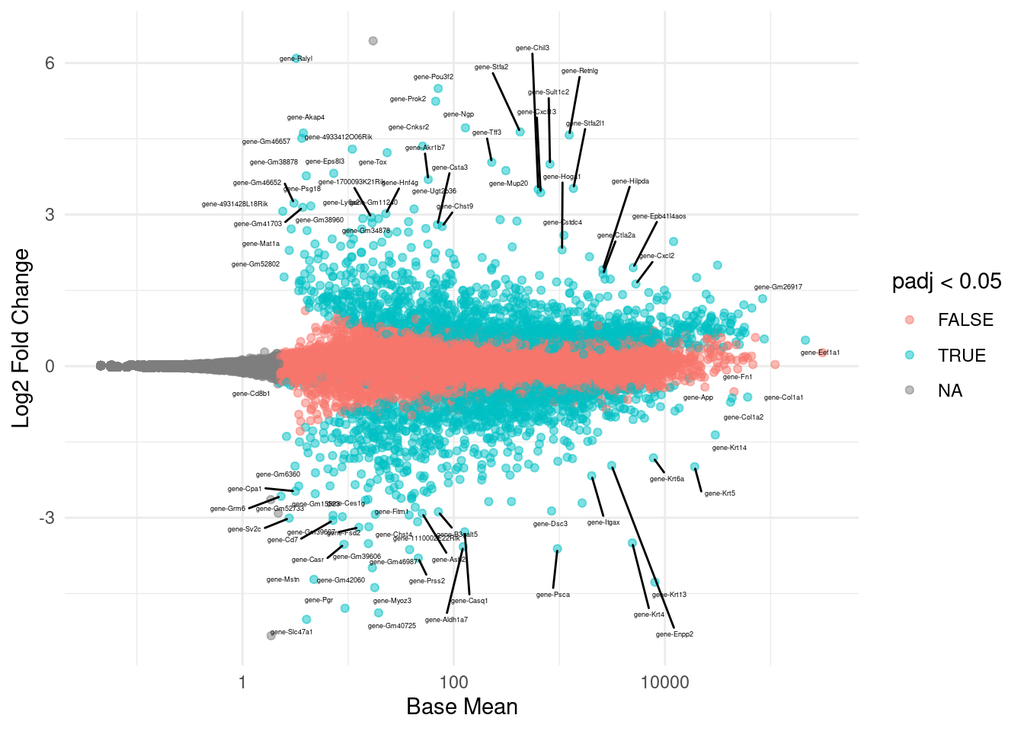

MAplot van de log van de gen-expressie

```r
#help("plotMA")

library(ggplot2)
library(ggrepel)

# data frame maken van resLFC_subset
ressub_df <- as.data.frame(resLFC_subset)

# voegt nieuwe kolom toe aan df met de genen
# (de rownames zijn dus blijkbaar de genen, dus deze neemt hij)
ressub_df$gene <- rownames(ressub_df)

# MAplot met ggplot2 maken:
# x=baseMean : gemiddelde expressie op x-as
# y=log2FoldChange " expressie log-2 verandering op de y-as
ggplot(ressub_df, aes(x=baseMean, y=log2FoldChange)) +
    # geom_point voegt punten toe aan de plot
    # color = padj < 0.05 : kleurt alle punten met p-waarde hoger dan 0.05
    # alpha=0.5 : zorgt ervoor dat de punten doorzichtig zijn (beter af te lezen bij overlap)
    geom_point(aes(color = padj < 0.05), alpha=0.5) +
    # scale_x_log10() : zorgt ervoor dat de as naar log aangepast wordt (zoals de input data)
    scale_x_log10() +

    # de labels toevoegen aan de plot:
    # padj < 0.05 & !is.na(padj)) : voegt alleen label toe als p-waarde significant is
    # max.overlaps : minder maken voor leesbaarheid, maar laat dan niet meer alle genen zien
    # size : is dit leesbaar genoeg ?
    geom_text_repel(data = subset(ressub_df, padj < 0.05 & !is.na(padj)),
                    aes(label = gene),
                    size=1.2,
                    max.overlaps = 30) +
    theme_minimal() +
    labs(x = "Base Mean", y = "Log2 Fold Change")
```

In de bovenstaande plot zie je de MAplot die we eerder ook hadden, maar dan in ggplot2. Ook zijn de genen toegevoegd. De padj < 0.05 staat voor de p-waarde. Alles wat kleiner dan 0.05 is statistisch significant en wordt verder gebruikt. Dus alleen alles met een p-waarde kleiner dan 0.05 wordt een gen bijgezet (en blauw gekleurd).  
Zoals eerder vermeld is, zijn de blauwe punten rechts in de grafiek het interessants, omdat die genen significant verschillen in expressie.

‘Gene-Eef 1 a 1’ staat het meest rechts. Dus dit is een interessant gen. Wat is de functie van dit gen?  
Dit gen helpt om aminozuur-gebonden tRNAs naar het ribosoom te brengen voor de eiwitsynthese. Als dit gen minder tot expressie komt, kan dat dus tot een verminderde eiwitsynthese leiden. Met een verminderde eiwitsynthese kan de celdeling langzamer gaan. Met een verminderde celdeling wordt schade minder snel gerepareerd. Ook werkt het immuunsysteem minder goed, aangezien er minder snel nieuwe cellen aangemaakt kunnen worden (zoals witte bloedcellen).  
[Bron: Gene-Eef 1 a 1](https://www.ncbi.nlm.nih.gov/gene/1915)

(Wat misschien interessant is: De isovorm (alfa 2) wordt geïdentificeerd als een auto-antigeen bij 66% van de patiënten met het Felty-syndroom. (Auto-antigen: antigen van je eigen lichaam dat je lichaam aanvalt, omdat het herkent wordt als vreemd). Dus de isovorm kan ook direct invloed hebben op het immuunsysteem.)

## Gen expressie vehicle vraag

Uit [Ramon](https://github.com/RamonReilman/GenomicsTranscriptomics/blob/main/Transcriptomics/logbooks/RamonReilman.Rmd) zijn plot bleek dat bij de NSG muis de vehicle een hoge gen-expressie had op het gene-Ces4a. Dit gen zorgt voor de afbraak van xenobiotische stoffen. Onze theorie is dat de stof die de vehicle toegediend heeft gekregen een xenobiotische stof is, waardoor de vehicle een hoge expressie heeft van gene-Ces4a. In [het artikel](https://pmc.ncbi.nlm.nih.gov/articles/PMC8363284/) staat de volgende zin: ‘BBN963 cells were treated with DMSO or 1 μM entinostat for 72 hours in vitro.’ Dit betekend dat de de stof waarschijnlijk [DMSO](https://pubmed.ncbi.nlm.nih.gov/17177172/) is. Dit is een xenobiotische stof, dus dit kan de hoge gen-expressie verklaren.

## Annotatie met biomart

Geprobeerd met [Jasper](https://github.com/RamonReilman/GenomicsTranscriptomics/blob/main/Transcriptomics/logbooks/JasperJonker.Rmd) en [Ramon](https://github.com/RamonReilman/GenomicsTranscriptomics/blob/main/Transcriptomics/logbooks/RamonReilman.Rmd). Onze dataset bevat teveel genen en de library connectie werkt niet, dus hebben we besloten om geen annotatie uit te voeren.

## Venn diagram eerste poging, klopt niet helemaal:

[Bron voor venndiagram](https://rpubs.com/Nishapaudel/DESeq2_sex_wise_dfs)

```r
head(counts)
```

```
##                    C57BL/6_Vehicle_r1 C57BL/6_Entinostat_r1 C57BL/6_Vehicle_r2
## MissingGeneID                    5859                  4387               7820
## gene-0610005C13Rik                  3                     0                  0
## gene-0610006L08Rik                  0                     1                  0
## gene-0610009E02Rik                  0                     1                  1
## gene-0610009L18Rik                 53                    29                 25
## gene-0610010K14Rik               1024                   790                881
##                    C57BL/6_Vehicle_r3 C57BL/6_Vehicle_r4 C57BL/6_Entinostat_r2
## MissingGeneID                    8707               3405                  3821
## gene-0610005C13Rik                  0                  0                     0
## gene-0610006L08Rik                  0                  0                     2
## gene-0610009E02Rik                  1                  0                     1
## gene-0610009L18Rik                 93                 43                    34
## gene-0610010K14Rik               1408                897                   523
##                    C57BL/6_Entinostat_r3 C57BL/6_Vehicle_r5 C57BL/6_Baseline_r1
## MissingGeneID                       3777               6823                4673
## gene-0610005C13Rik                     1                  0                   0
## gene-0610006L08Rik                     0                  0                   0
## gene-0610009E02Rik                     1                  4                   0
## gene-0610009L18Rik                    44                 93                  25
## gene-0610010K14Rik                   492               1304                 975
##                    C57BL/6_Baseline_r2 C57BL/6_Entinostat_r4
## MissingGeneID                     7162                  2160
## gene-0610005C13Rik                   0                     1
## gene-0610006L08Rik                   0                     1
## gene-0610009E02Rik                   0                     1
## gene-0610009L18Rik                  55                    15
## gene-0610010K14Rik                1390                   419
##                    C57BL/6_Baseline_r3 C57BL/6_Entinostat_r5
## MissingGeneID                     5096                  2718
## gene-0610005C13Rik                   0                     0
## gene-0610006L08Rik                   0                     0
## gene-0610009E02Rik                   0                     4
## gene-0610009L18Rik                  24                    49
## gene-0610010K14Rik                 972                   676
##                    C57BL/6_Entinostat_r6 C57BL/6_Vehicle_r6 C57BL/6_Baseline_r4
## MissingGeneID                       3870               9562                5163
## gene-0610005C13Rik                     0                  0                   0
## gene-0610006L08Rik                     0                  0                   0
## gene-0610009E02Rik                     6                  0                   2
```

[output cut: 22 more lines]

```
## gene-0610010K14Rik              1528              1339               387
##                    NSG_Entinostat_r5 NSG_Vehicle_r1 NSG_Vehicle_r2
## MissingGeneID                  12470           5393           7122
## gene-0610005C13Rik                 2              2              1
## gene-0610006L08Rik                 1              0              0
## gene-0610009E02Rik                13              6             11
## gene-0610009L18Rik               113             41             50
## gene-0610010K14Rik              1393            735           1145
##                    NSG_Vehicle_r3 NSG_Vehicle_r4 NSG_Vehicle_r5
## MissingGeneID                8495           8854           7730
## gene-0610005C13Rik              2              4              2
## gene-0610006L08Rik              0              0              1
## gene-0610009E02Rik              5              8              4
## gene-0610009L18Rik            122            150            160
## gene-0610010K14Rik           1618           1689           1511
```

Namen elke kolom:

```r
library(DESeq2)

print(colnames(counts))
```

```
##  [1] "C57BL/6_Vehicle_r1"    "C57BL/6_Entinostat_r1" "C57BL/6_Vehicle_r2"
##  [4] "C57BL/6_Vehicle_r3"    "C57BL/6_Vehicle_r4"    "C57BL/6_Entinostat_r2"
##  [7] "C57BL/6_Entinostat_r3" "C57BL/6_Vehicle_r5"    "C57BL/6_Baseline_r1"
## [10] "C57BL/6_Baseline_r2"   "C57BL/6_Entinostat_r4" "C57BL/6_Baseline_r3"
## [13] "C57BL/6_Entinostat_r5" "C57BL/6_Entinostat_r6" "C57BL/6_Vehicle_r6"
## [16] "C57BL/6_Baseline_r4"   "NSG_Baseline_r1"       "NSG_Baseline_r2"
## [19] "NSG_Baseline_r3"       "NSG_Baseline_r4"       "NSG_Baseline_r5"
## [22] "NSG_Entinostat_r1"     "NSG_Entinostat_r2"     "NSG_Entinostat_r3"
## [25] "NSG_Entinostat_r4"     "NSG_Entinostat_r5"     "NSG_Vehicle_r1"
## [28] "NSG_Vehicle_r2"        "NSG_Vehicle_r3"        "NSG_Vehicle_r4"
## [31] "NSG_Vehicle_r5"
```

```r
dim(counts)
```

```
## [1] 41641    31
```

Verdelen in C57BL6-muis en NSG-muis (er wordt een genen-count per kolom aangemaakt).

```r
desired_columns_C57BL6 <- c("C57BL/6_Vehicle_r1", "C57BL/6_Vehicle_r2", "C57BL/6_Vehicle_r3", "C57BL/6_Vehicle_r4", "C57BL/6_Vehicle_r5", "C57BL/6_Vehicle_r6", "C57BL/6_Baseline_r1", "C57BL/6_Baseline_r2",  "C57BL/6_Baseline_r3", "C57BL/6_Baseline_r4", "C57BL/6_Entinostat_r1", "C57BL/6_Entinostat_r2", "C57BL/6_Entinostat_r3", "C57BL/6_Entinostat_r4",  "C57BL/6_Entinostat_r5", "C57BL/6_Entinostat_r6")

# Rearrange the columns based on the desired order
data_rearranged_C57BL6 <- counts[, desired_columns_C57BL6]
```

```r
head(data_rearranged_C57BL6)
```

```
##                    C57BL/6_Vehicle_r1 C57BL/6_Vehicle_r2 C57BL/6_Vehicle_r3
## MissingGeneID                    5859               7820               8707
## gene-0610005C13Rik                  3                  0                  0
## gene-0610006L08Rik                  0                  0                  0
## gene-0610009E02Rik                  0                  1                  1
## gene-0610009L18Rik                 53                 25                 93
## gene-0610010K14Rik               1024                881               1408
##                    C57BL/6_Vehicle_r4 C57BL/6_Vehicle_r5 C57BL/6_Vehicle_r6
## MissingGeneID                    3405               6823               9562
## gene-0610005C13Rik                  0                  0                  0
## gene-0610006L08Rik                  0                  0                  0
## gene-0610009E02Rik                  0                  4                  0
## gene-0610009L18Rik                 43                 93                 43
## gene-0610010K14Rik                897               1304                964
##                    C57BL/6_Baseline_r1 C57BL/6_Baseline_r2 C57BL/6_Baseline_r3
## MissingGeneID                     4673                7162                5096
## gene-0610005C13Rik                   0                   0                   0
## gene-0610006L08Rik                   0                   0                   0
## gene-0610009E02Rik                   0                   0                   0
## gene-0610009L18Rik                  25                  55                  24
## gene-0610010K14Rik                 975                1390                 972
##                    C57BL/6_Baseline_r4 C57BL/6_Entinostat_r1
## MissingGeneID                     5163                  4387
## gene-0610005C13Rik                   0                     0
## gene-0610006L08Rik                   0                     1
## gene-0610009E02Rik                   2                     1
## gene-0610009L18Rik                  45                    29
## gene-0610010K14Rik                 876                   790
##                    C57BL/6_Entinostat_r2 C57BL/6_Entinostat_r3
## MissingGeneID                       3821                  3777
## gene-0610005C13Rik                     0                     1
## gene-0610006L08Rik                     2                     0
## gene-0610009E02Rik                     1                     1
## gene-0610009L18Rik                    34                    44
## gene-0610010K14Rik                   523                   492
##                    C57BL/6_Entinostat_r4 C57BL/6_Entinostat_r5
## MissingGeneID                       2160                  2718
## gene-0610005C13Rik                     1                     0
## gene-0610006L08Rik                     1                     0
## gene-0610009E02Rik                     1                     4
## gene-0610009L18Rik                    15                    49
## gene-0610010K14Rik                   419                   676
##                    C57BL/6_Entinostat_r6
## MissingGeneID                       3870
## gene-0610005C13Rik                     0
## gene-0610006L08Rik                     0
## gene-0610009E02Rik                     6
## gene-0610009L18Rik                    34
## gene-0610010K14Rik                   431
```

Nu voor de NSG-muis:

```r
desired_columns_NSG <- c( "NSG_Vehicle_r1", "NSG_Vehicle_r2", "NSG_Vehicle_r3", "NSG_Vehicle_r4", "NSG_Vehicle_r5", "NSG_Baseline_r1", "NSG_Baseline_r2", "NSG_Baseline_r3", "NSG_Baseline_r4", "NSG_Baseline_r5", "NSG_Entinostat_r1", "NSG_Entinostat_r2", "NSG_Entinostat_r3", "NSG_Entinostat_r4", "NSG_Entinostat_r5")

# Rearrange the columns based on the desired order
data_rearranged_NSG <- counts[, desired_columns_NSG]
```

```r
head(data_rearranged_NSG)
```

```
##                    NSG_Vehicle_r1 NSG_Vehicle_r2 NSG_Vehicle_r3 NSG_Vehicle_r4
## MissingGeneID                5393           7122           8495           8854
## gene-0610005C13Rik              2              1              2              4
## gene-0610006L08Rik              0              0              0              0
## gene-0610009E02Rik              6             11              5              8
## gene-0610009L18Rik             41             50            122            150
## gene-0610010K14Rik            735           1145           1618           1689
##                    NSG_Vehicle_r5 NSG_Baseline_r1 NSG_Baseline_r2
## MissingGeneID                7730            8453            8045
## gene-0610005C13Rik              2               4               1
## gene-0610006L08Rik              1               0               0
## gene-0610009E02Rik              4               7               4
## gene-0610009L18Rik            160              38              47
## gene-0610010K14Rik           1511             967            1298
##                    NSG_Baseline_r3 NSG_Baseline_r4 NSG_Baseline_r5
## MissingGeneID                 5803            6777            8639
## gene-0610005C13Rik               2               1               3
## gene-0610006L08Rik               0               1               0
## gene-0610009E02Rik               7               8              10
## gene-0610009L18Rik              31              45              48
## gene-0610010K14Rik             664            1001            1336
##                    NSG_Entinostat_r1 NSG_Entinostat_r2 NSG_Entinostat_r3
## MissingGeneID                   6767              9366              9204
## gene-0610005C13Rik                 1                 6                 2
## gene-0610006L08Rik                 0                 0                 0
## gene-0610009E02Rik                 6                 5                 6
## gene-0610009L18Rik                95               139               124
## gene-0610010K14Rik              1470              1528              1339
##                    NSG_Entinostat_r4 NSG_Entinostat_r5
## MissingGeneID                   3295             12470
## gene-0610005C13Rik                 0                 2
## gene-0610006L08Rik                 0                 1
## gene-0610009E02Rik                 0                13
## gene-0610009L18Rik                64               113
## gene-0610010K14Rik               387              1393
```

Condities per muis toevoegen:

```r
sampleinfo_NSG <- data.frame(
  row.names = colnames(data_rearranged_NSG),
  condition = c("Vehicle", "Vehicle", "Vehicle", "Vehicle", "Vehicle",
                "Baseline", "Baseline", "Baseline", "Baseline", "Baseline",
                "Entinostat", "Entinostat", "Entinostat", "Entinostat", "Entinostat")
)
```

```r
sampleinfo_C57BL6 <- data.frame(
  row.names = colnames(data_rearranged_C57BL6),
  condition = c("Vehicle", "Vehicle", "Vehicle", "Vehicle", "Vehicle", "Vehicle",
                "Baseline", "Baseline", "Baseline", "Baseline",
                "Entinostat", "Entinostat", "Entinostat", "Entinostat", "Entinostat", "Entinostat")
)
```

Analyse van maken:

```r
dds_NSG <- DESeqDataSetFromMatrix(countData = data_rearranged_NSG, colData = sampleinfo_NSG, design = ~ condition)
dds_NSG <- DESeq(dds_NSG)
res_NSG <- results(dds_NSG)
```

```r
dds_C57BL6 <- DESeqDataSetFromMatrix(countData = data_rearranged_C57BL6, colData = sampleinfo_C57BL6, design = ~ condition)
dds_C57BL6 <- DESeq(dds_C57BL6)
res_C57BL6 <- results(dds_C57BL6)
```

Belangrijke genen eruit halen:

```r
# !is.na, is nodig omdat R anders zeurt over na waardes
upregulated_C57BL6 <- rownames(res_C57BL6[!is.na(res_C57BL6$log2FoldChange) & res_C57BL6$log2FoldChange > 0 & !is.na(res_C57BL6$padj) & res_C57BL6$padj <= 0.05, ])
upregulated_NSG <- rownames(res_NSG[!is.na(res_NSG$log2FoldChange) & res_NSG$log2FoldChange > 0 & !is.na(res_NSG$padj) & res_NSG$padj <= 0.05, ])
```

Package installeren:

```r
# install.packages("VennDiagram")
```

```r
library(VennDiagram)
```

Venn diagram maken:

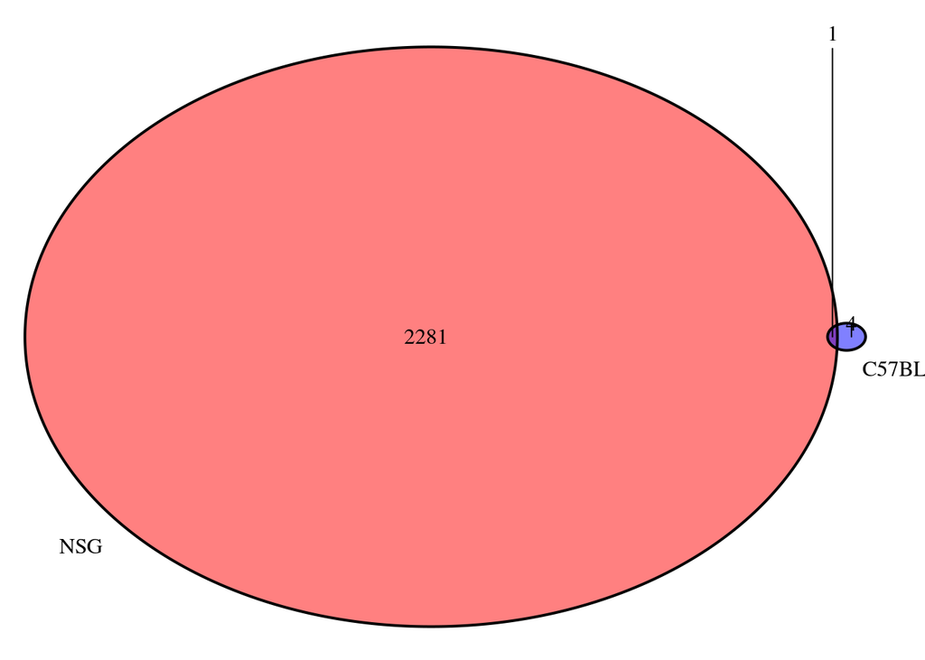

```r
venn.plot <- draw.pairwise.venn(
  area1 = length(upregulated_C57BL6),
  area2 = length(upregulated_NSG),
  cross.area = length(intersect(upregulated_C57BL6, upregulated_NSG)),
  category = c("C57BL6", "NSG"),
  fill = c("blue", "red")
)
```

Laten zien diagram:

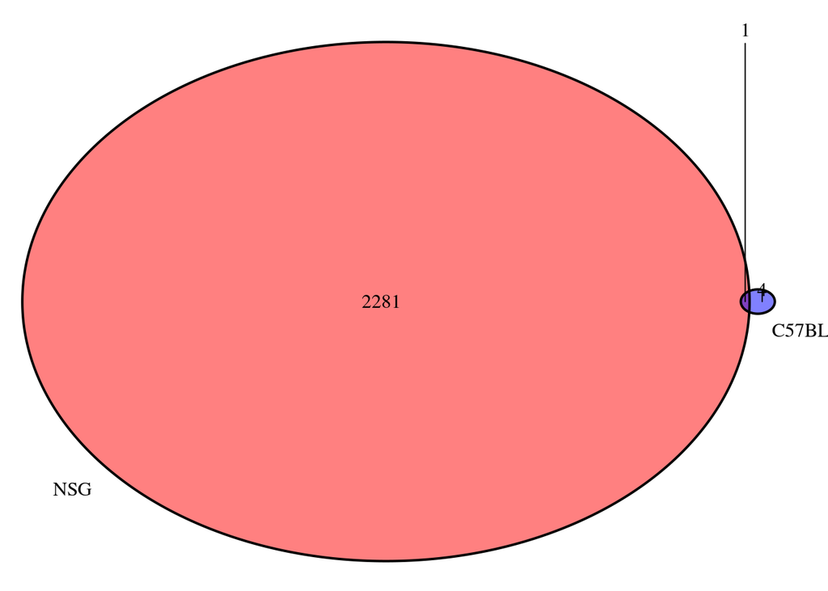

```r
grid.newpage()
grid.draw(venn.plot)
```

Dit gaat niet helemaal goed. Diagram nodig van elke treatment apart van soort 1 tegen soort 2. De code is steeds hetzelfde, maar dan met de juiste treatment (entinostat, vehicle, baseline).

## Venndiagram entinostat:

Verdelen in C57BL6-muis en NSG-muis voor alleen de entinostat groep (er wordt een genen-count per kolom aangemaakt).

```r
desired_columns_C57BL6_entinostat <- c("C57BL/6_Entinostat_r1", "C57BL/6_Entinostat_r2", "C57BL/6_Entinostat_r3", "C57BL/6_Entinostat_r4", "C57BL/6_Entinostat_r5", "C57BL/6_Entinostat_r6")

# Rearrange the columns based on the desired order
data_rearranged_C57BL6_entinostat <- counts[, desired_columns_C57BL6_entinostat]
```

```r
head(data_rearranged_C57BL6_entinostat)
```

```
##                    C57BL/6_Entinostat_r1 C57BL/6_Entinostat_r2
## MissingGeneID                       4387                  3821
## gene-0610005C13Rik                     0                     0
## gene-0610006L08Rik                     1                     2
## gene-0610009E02Rik                     1                     1
## gene-0610009L18Rik                    29                    34
## gene-0610010K14Rik                   790                   523
##                    C57BL/6_Entinostat_r3 C57BL/6_Entinostat_r4
## MissingGeneID                       3777                  2160
## gene-0610005C13Rik                     1                     1
## gene-0610006L08Rik                     0                     1
## gene-0610009E02Rik                     1                     1
## gene-0610009L18Rik                    44                    15
## gene-0610010K14Rik                   492                   419
##                    C57BL/6_Entinostat_r5 C57BL/6_Entinostat_r6
## MissingGeneID                       2718                  3870
## gene-0610005C13Rik                     0                     0
## gene-0610006L08Rik                     0                     0
## gene-0610009E02Rik                     4                     6
## gene-0610009L18Rik                    49                    34
## gene-0610010K14Rik                   676                   431
```

```r
# zijn er dubbele kolomnamen ?
any(duplicated(colnames(counts)))
```

```
## [1] FALSE
```

```r
#en zijn de namen goed ingevoerd ?
all(desired_columns_C57BL6_entinostat %in% colnames(counts))
```

```
## [1] TRUE
```

Maar uit de tests komen dat er geen dubbele kolom namen zijn en dat de namen die ik heb ingevoerd kloppen ?

```r
print(colnames(data_rearranged_C57BL6_entinostat))
```

```
## [1] "C57BL/6_Entinostat_r1" "C57BL/6_Entinostat_r2" "C57BL/6_Entinostat_r3"
## [4] "C57BL/6_Entinostat_r4" "C57BL/6_Entinostat_r5" "C57BL/6_Entinostat_r6"
```

Bij de NSG gaat het wel goed:

```r
desired_columns_NSG_entinostat <- c("NSG_Entinostat_r1", "NSG_Entinostat_r2", "NSG_Entinostat_r3", "NSG_Entinostat_r4", "NSG_Entinostat_r5")

# Rearrange the columns based on the desired order
data_rearranged_NSG_entinostat <- counts[, desired_columns_NSG_entinostat]
```

```r
head(data_rearranged_NSG_entinostat)
```

```
##                    NSG_Entinostat_r1 NSG_Entinostat_r2 NSG_Entinostat_r3
## MissingGeneID                   6767              9366              9204
## gene-0610005C13Rik                 1                 6                 2
## gene-0610006L08Rik                 0                 0                 0
## gene-0610009E02Rik                 6                 5                 6
## gene-0610009L18Rik                95               139               124
## gene-0610010K14Rik              1470              1528              1339
##                    NSG_Entinostat_r4 NSG_Entinostat_r5
## MissingGeneID                   3295             12470
## gene-0610005C13Rik                 0                 2
## gene-0610006L08Rik                 0                 1
## gene-0610009E02Rik                 0                13
## gene-0610009L18Rik                64               113
## gene-0610010K14Rik               387              1393
```

Dus voor nu aannemen dat het visueel foutje is.

Condities per muis toevoegen:

```r
sampleinfo_NSG_entinostat <- data.frame(
  row.names = colnames(data_rearranged_NSG_entinostat),
  condition = c("Entinostat", "Entinostat", "Entinostat", "Entinostat", "Entinostat")
  )
```

```r
sampleinfo_C57BL6_entinostat <- data.frame(
  row.names = colnames(data_rearranged_C57BL6_entinostat),
  condition = c("Entinostat", "Entinostat", "Entinostat", "Entinostat", "Entinostat", "Entinostat")
  )
```

Analyse van maken:

```r
# design is 1, omdat alles Entinostat is
dds_NSG_entinostat <- DESeqDataSetFromMatrix(countData = data_rearranged_NSG_entinostat, colData = sampleinfo_NSG_entinostat, design = ~ 1)
dds_NSG_entinostat <- DESeq(dds_NSG_entinostat)
res_NSG_entinostat <- results(dds_NSG_entinostat)
```

```r
dds_C57BL6_entinostat <- DESeqDataSetFromMatrix(countData = data_rearranged_C57BL6_entinostat, colData = sampleinfo_C57BL6_entinostat, design = ~ 1)
dds_C57BL6_entinostat <- DESeq(dds_C57BL6_entinostat)
res_C57BL6_entinostat <- results(dds_C57BL6_entinostat)
```

Belangrijke genen eruit halen:

```r
# !is.na, is nodig omdat R anders zeurt over na waardes
upregulated_C57BL6_entinostat <- rownames(res_C57BL6_entinostat[!is.na(res_C57BL6_entinostat$log2FoldChange) & res_C57BL6_entinostat$log2FoldChange > 0 & !is.na(res_C57BL6_entinostat$padj) & res_C57BL6_entinostat$padj <= 0.05, ])
upregulated_NSG_entinostat <- rownames(res_NSG_entinostat[!is.na(res_NSG_entinostat$log2FoldChange) & res_NSG_entinostat$log2FoldChange > 0 & !is.na(res_NSG_entinostat$padj) & res_NSG_entinostat$padj <= 0.05, ])
```

Venn diagram maken:

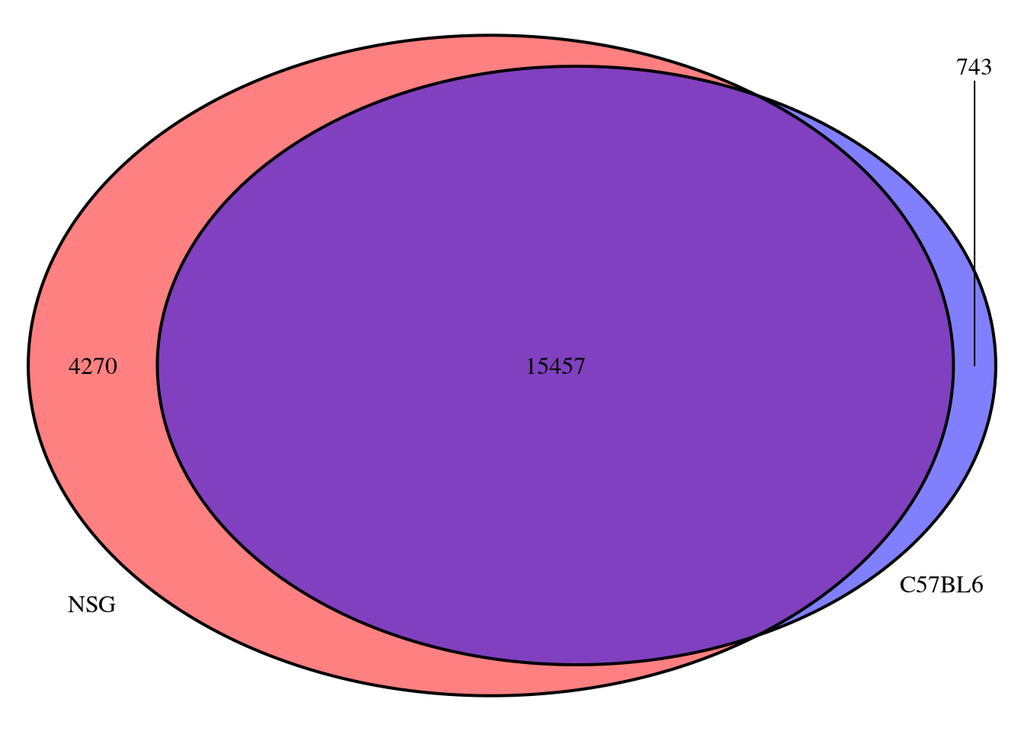

```r
library(VennDiagram)

venn.plot_entinostat <- draw.pairwise.venn(
  area1 = length(upregulated_C57BL6_entinostat),
  area2 = length(upregulated_NSG_entinostat),
  cross.area = length(intersect(upregulated_C57BL6_entinostat, upregulated_NSG_entinostat)),
  category = c("C57BL6", "NSG"),
  fill = c("blue", "red")
)
```

Laten zien diagram:

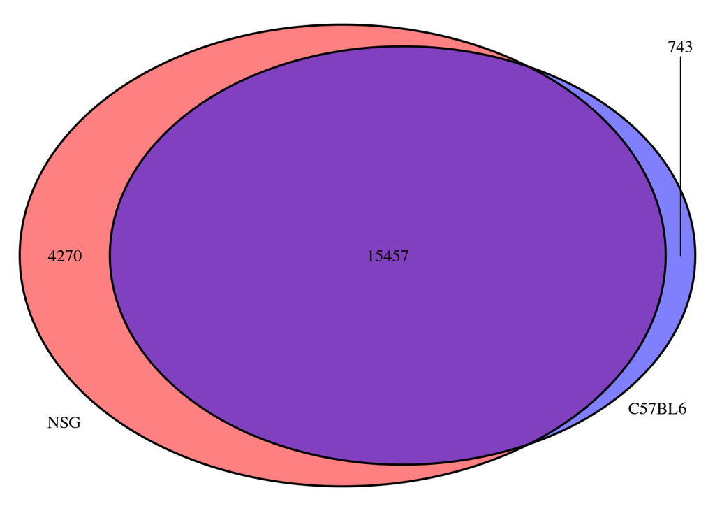

venndiagram van NSG-entinostat tegen C57BL6-Entinostat

```r
grid.newpage()
grid.draw(venn.plot_entinostat)
```

In de venndiagrammen zie je de upregulated genen weergegeven van de Entinostat groepen. De genen die in de overlap staan, zijn significant upregulated in beide muizen, terwijl de genen in de aparte delen van de Venn-cirkel alleen in één van de twee muizen significant upregulated zijn.

## Venndiagram Vehicle:

Verdelen in C57BL6-muis en NSG-muis voor alleen de vehicle groep (er wordt een genen-count per kolom aangemaakt).

```r
desired_columns_C57BL6_vehicle <- c("C57BL/6_Vehicle_r1", "C57BL/6_Vehicle_r2", "C57BL/6_Vehicle_r3", "C57BL/6_Vehicle_r4", "C57BL/6_Vehicle_r5", "C57BL/6_Vehicle_r6")

# Rearrange the columns based on the desired order
data_rearranged_C57BL6_vehicle <- counts[, desired_columns_C57BL6_vehicle]
```

```r
head(data_rearranged_C57BL6_vehicle)
```

```
##                    C57BL/6_Vehicle_r1 C57BL/6_Vehicle_r2 C57BL/6_Vehicle_r3
## MissingGeneID                    5859               7820               8707
## gene-0610005C13Rik                  3                  0                  0
## gene-0610006L08Rik                  0                  0                  0
## gene-0610009E02Rik                  0                  1                  1
## gene-0610009L18Rik                 53                 25                 93
## gene-0610010K14Rik               1024                881               1408
##                    C57BL/6_Vehicle_r4 C57BL/6_Vehicle_r5 C57BL/6_Vehicle_r6
## MissingGeneID                    3405               6823               9562
## gene-0610005C13Rik                  0                  0                  0
## gene-0610006L08Rik                  0                  0                  0
## gene-0610009E02Rik                  0                  4                  0
## gene-0610009L18Rik                 43                 93                 43
## gene-0610010K14Rik                897               1304                964
```

De NSG-muis:

```r
desired_columns_NSG_vehicle <- c( "NSG_Vehicle_r1", "NSG_Vehicle_r2", "NSG_Vehicle_r3", "NSG_Vehicle_r4", "NSG_Vehicle_r5")

# Rearrange the columns based on the desired order
data_rearranged_NSG_vehicle <- counts[, desired_columns_NSG_vehicle]
```

```r
head(data_rearranged_NSG_vehicle)
```

```
##                    NSG_Vehicle_r1 NSG_Vehicle_r2 NSG_Vehicle_r3 NSG_Vehicle_r4
## MissingGeneID                5393           7122           8495           8854
## gene-0610005C13Rik              2              1              2              4
## gene-0610006L08Rik              0              0              0              0
## gene-0610009E02Rik              6             11              5              8
## gene-0610009L18Rik             41             50            122            150
## gene-0610010K14Rik            735           1145           1618           1689
##                    NSG_Vehicle_r5
## MissingGeneID                7730
## gene-0610005C13Rik              2
## gene-0610006L08Rik              1
## gene-0610009E02Rik              4
## gene-0610009L18Rik            160
## gene-0610010K14Rik           1511
```

Condities per muis toevoegen:

```r
sampleinfo_NSG_vehicle <- data.frame(
  row.names = colnames(data_rearranged_NSG_vehicle),
  condition = c("Vehicle", "Vehicle", "Vehicle", "Vehicle", "Vehicle")
  )
```

```r
sampleinfo_C57BL6_vehicle <- data.frame(
  row.names = colnames(data_rearranged_C57BL6_vehicle),
  condition = c("Vehicle", "Vehicle", "Vehicle", "Vehicle", "Vehicle", "Vehicle")
  )
```

Analyse van maken:

```r
# design is 1, omdat alles Entinostat is
dds_NSG_vehicle <- DESeqDataSetFromMatrix(countData = data_rearranged_NSG_vehicle, colData = sampleinfo_NSG_vehicle, design = ~ 1)
dds_NSG_vehicle <- DESeq(dds_NSG_vehicle)
res_NSG_vehicle <- results(dds_NSG_vehicle)
```

```r
dds_C57BL6_vehicle <- DESeqDataSetFromMatrix(countData = data_rearranged_C57BL6_vehicle, colData = sampleinfo_C57BL6_vehicle, design = ~ 1)
dds_C57BL6_vehicle <- DESeq(dds_C57BL6_vehicle)
res_C57BL6_vehicle <- results(dds_C57BL6_vehicle)
```

Belangrijke genen eruit halen:

```r
# !is.na, is nodig omdat R anders zeurt over na waardes
upregulated_C57BL6_vehicle <- rownames(res_C57BL6_vehicle[!is.na(res_C57BL6_vehicle$log2FoldChange) & res_C57BL6_vehicle$log2FoldChange > 0 & !is.na(res_C57BL6_vehicle$padj) & res_C57BL6_vehicle$padj <= 0.05, ])
upregulated_NSG_vehicle <- rownames(res_NSG_vehicle[!is.na(res_NSG_vehicle$log2FoldChange) & res_NSG_vehicle$log2FoldChange > 0 & !is.na(res_NSG_vehicle$padj) & res_NSG_vehicle$padj <= 0.05, ])
```

Venn diagram maken:

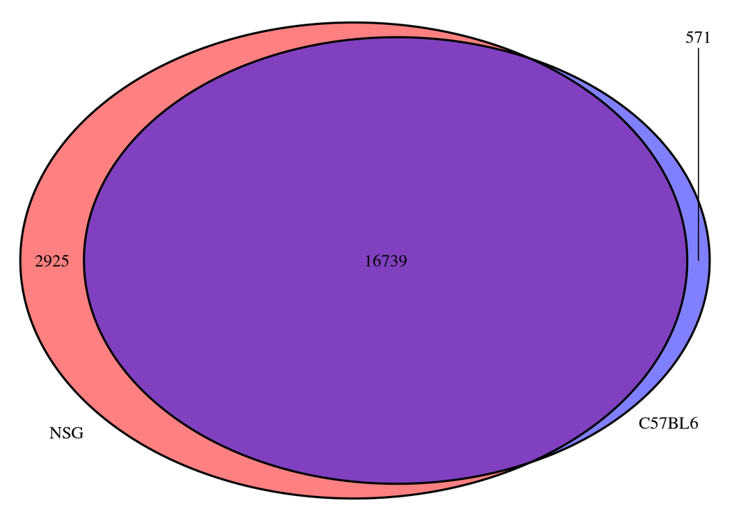

```r
library(VennDiagram)

venn.plot_vehicle <- draw.pairwise.venn(
  area1 = length(upregulated_C57BL6_vehicle),
  area2 = length(upregulated_NSG_vehicle),
  cross.area = length(intersect(upregulated_C57BL6_vehicle, upregulated_NSG_vehicle)),
  category = c("C57BL6", "NSG"),
  fill = c("blue", "red")
)
```

Laten zien diagram:

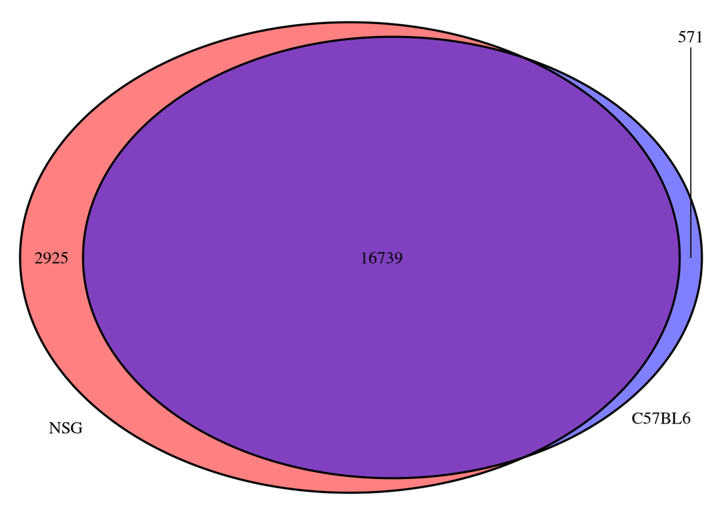

venndiagram van NSG-Vehicle tegen C57BL6-Vehicle

```r
grid.newpage()
grid.draw(venn.plot_vehicle)
```

In de venndiagrammen zie je de upregulated genen weergegeven van de Vehicle groepen. De genen die in de overlap staan, zijn significant upregulated in beide muizen, terwijl de genen in de aparte delen van de Venn-cirkel alleen in één van de twee muizen significant upregulated zijn.

## Venndiagram Baseline:

Verdelen in C57BL6-muis en NSG-muis voor alleen de baseline groep (er wordt een genen-count per kolom aangemaakt).

```r
desired_columns_C57BL6_baseline <- c("C57BL/6_Baseline_r1", "C57BL/6_Baseline_r2",  "C57BL/6_Baseline_r3", "C57BL/6_Baseline_r4")

# Rearrange the columns based on the desired order
data_rearranged_C57BL6_baseline <- counts[, desired_columns_C57BL6_baseline]
```

```r
head(data_rearranged_C57BL6_baseline)
```

```
##                    C57BL/6_Baseline_r1 C57BL/6_Baseline_r2 C57BL/6_Baseline_r3
## MissingGeneID                     4673                7162                5096
## gene-0610005C13Rik                   0                   0                   0
## gene-0610006L08Rik                   0                   0                   0
## gene-0610009E02Rik                   0                   0                   0
## gene-0610009L18Rik                  25                  55                  24
## gene-0610010K14Rik                 975                1390                 972
##                    C57BL/6_Baseline_r4
## MissingGeneID                     5163
## gene-0610005C13Rik                   0
## gene-0610006L08Rik                   0
## gene-0610009E02Rik                   2
## gene-0610009L18Rik                  45
## gene-0610010K14Rik                 876
```

De NSG-muis:

```r
desired_columns_NSG_baseline <- c("NSG_Baseline_r1", "NSG_Baseline_r2", "NSG_Baseline_r3", "NSG_Baseline_r4", "NSG_Baseline_r5")


# Rearrange the columns based on the desired order
data_rearranged_NSG_baseline <- counts[, desired_columns_NSG_baseline]
```

```r
head(data_rearranged_NSG_baseline)
```

```
##                    NSG_Baseline_r1 NSG_Baseline_r2 NSG_Baseline_r3
## MissingGeneID                 8453            8045            5803
## gene-0610005C13Rik               4               1               2
## gene-0610006L08Rik               0               0               0
## gene-0610009E02Rik               7               4               7
## gene-0610009L18Rik              38              47              31
## gene-0610010K14Rik             967            1298             664
##                    NSG_Baseline_r4 NSG_Baseline_r5
## MissingGeneID                 6777            8639
## gene-0610005C13Rik               1               3
## gene-0610006L08Rik               1               0
## gene-0610009E02Rik               8              10
## gene-0610009L18Rik              45              48
## gene-0610010K14Rik            1001            1336
```

Condities per muis toevoegen:

```r
sampleinfo_NSG_baseline <- data.frame(
  row.names = colnames(data_rearranged_NSG_baseline),
  condition = c("Baseline", "Baseline", "Baseline", "Baseline", "Baseline")
  )
```

```r
sampleinfo_C57BL6_baseline <- data.frame(
  row.names = colnames(data_rearranged_C57BL6_baseline),
  condition = c("Baseline", "Baseline", "Baseline", "Baseline")
  )
```

Analyse van maken:

```r
# design is 1, omdat alles Baseline is
dds_NSG_baseline <- DESeqDataSetFromMatrix(countData = data_rearranged_NSG_baseline, colData = sampleinfo_NSG_baseline, design = ~ 1)
dds_NSG_baseline <- DESeq(dds_NSG_baseline)
res_NSG_baseline <- results(dds_NSG_baseline)
```

```r
dds_C57BL6_baseline <- DESeqDataSetFromMatrix(countData = data_rearranged_C57BL6_baseline, colData = sampleinfo_C57BL6_baseline, design = ~ 1)
dds_C57BL6_baseline <- DESeq(dds_C57BL6_baseline)
res_C57BL6_baseline <- results(dds_C57BL6_baseline)
```

Belangrijke genen eruit halen:

```r
# !is.na, is nodig omdat R anders zeurt over na waardes
upregulated_C57BL6_baseline <- rownames(res_C57BL6_baseline[!is.na(res_C57BL6_baseline$log2FoldChange) & res_C57BL6_baseline$log2FoldChange > 0 & !is.na(res_C57BL6_baseline$padj) & res_C57BL6_baseline$padj <= 0.05, ])
upregulated_NSG_baseline <- rownames(res_NSG_baseline[!is.na(res_NSG_baseline$log2FoldChange) & res_NSG_baseline$log2FoldChange > 0 & !is.na(res_NSG_baseline$padj) & res_NSG_baseline$padj <= 0.05, ])
```

Venn diagram maken:

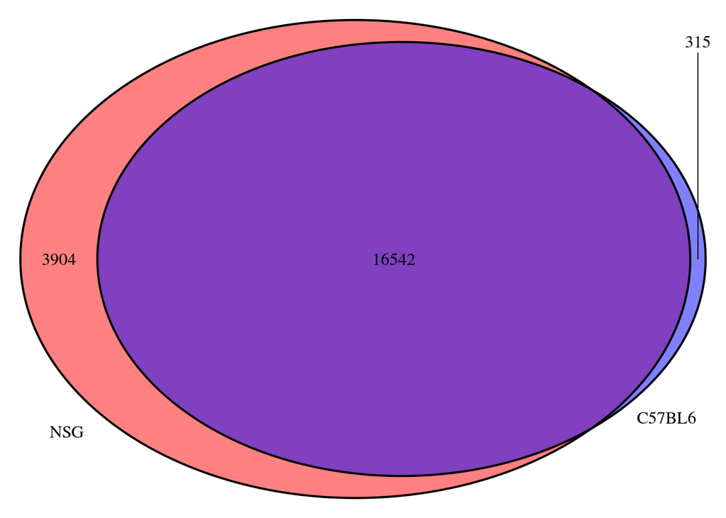

```r
library(VennDiagram)

venn.plot_baseline <- draw.pairwise.venn(
  area1 = length(upregulated_C57BL6_baseline),
  area2 = length(upregulated_NSG_baseline),
  cross.area = length(intersect(upregulated_C57BL6_baseline, upregulated_NSG_baseline)),
  category = c("C57BL6", "NSG"),
  fill = c("blue", "red")
)
```

Laten zien diagram:

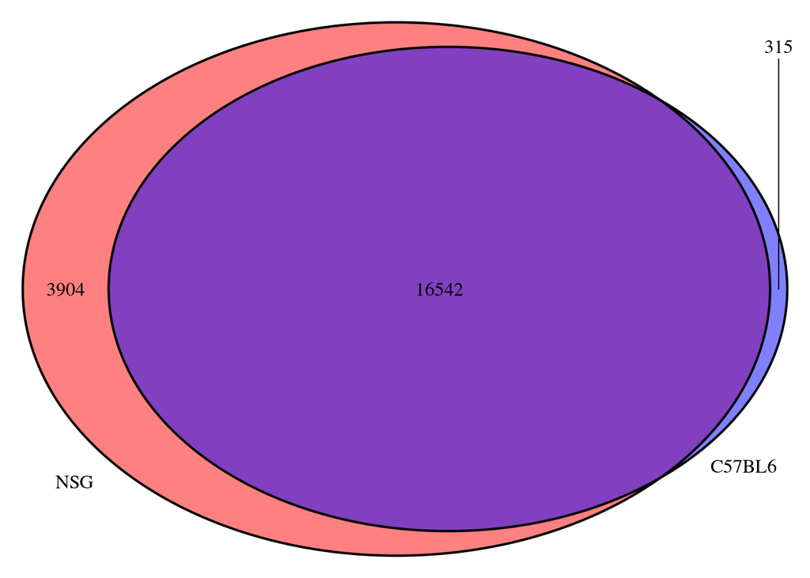

venndiagram van NSG-Baseline tegen C57BL6-Baseline

```r
grid.newpage()
grid.draw(venn.plot_baseline)
```

In de venndiagrammen zie je de upregulated genen weergegeven van de Baseline groepen. De genen die in de overlap staan, zijn significant upregulated in beide muizen, terwijl de genen in de aparte delen van de Venn-cirkel alleen in één van de twee muizen significant upregulated zijn.

## Vergelijken venndiagrammen:

Er is de meeste overlap bij vehicle(16739) en baseline(16542)(Entinostat heeft een overlap van 15457). Waarin de vehicle(16739) de meeste overlap heeft.

## Volcano plot

Van de baseline en entinostat:

```r
library(EnhancedVolcano)
```

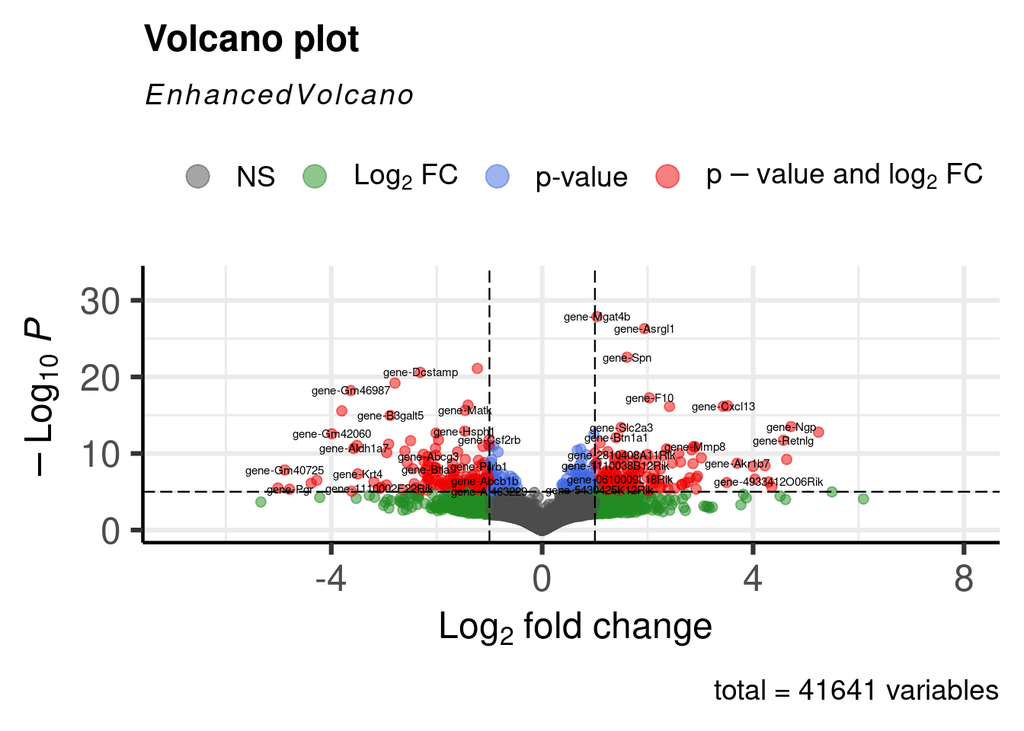

Volcano plot van Baseline en entinostat

```r
EnhancedVolcano(resLFC_subset,
                lab = rownames(resLFC_subset),
                x = 'log2FoldChange',
                y = 'pvalue',
                labSize = 2)
```

X-as:  
Log2 fold change laat zien hoe groot het verschil van gen-expressie is tussen de baseline en entinostat.  
Alles aan de rechterkant: de gen-expressie is hoger bij baseline dan bij entinostat.  
Alles aan de linkerkant: de gen-expressie is hoger bij de entinostat dan bij baseline.  
Y-as:  
-Log10(p-waarde) laat zien hoe hoog de significantie is in het verschil tussen de gen-expressie (hoe hoger hoe meer significantie).

Het lijkt me dus interessant om te kijken naar de linkerkant. Want ik wil kijken welke genen entinostat mogelijk tot een hogere expressie brengt. (Baseline is totdat de tumor een bepaalde grootte heeft. Entinostat is als na die grootte entinostat is gegeven). De meest interessante (hoog expressie verschil en hoge significantie) is gene-Gm46987, maar daar kan ik niet veel over vinden. Welke ook interessant is, is gene-Dcstamp. Dit gen reguleert Dendritische cellen(soort witte bloedcellen). En zorgt er dus voor dat het immuunsysteem weet welke cellen deze moet aanvallen (en ook zichzelf niet aanvalt). Dat de expressie van dit gen hoger is nadat de tumor groter is en behandeld wordt met entinostat is dus een goed teken. Het kan dus betekenen dat entinostat ervoor zorgt dat de gen-expressie van dit gen hoger wordt. Maar het kan ook betekenen dat de tumor eerst nog te klein was(bij de baseline) om de gen-expressie van dit gen te verhogen. Je zou hiervoor eigenlijk naar het verschil van de gen-expressie moeten kijken van de vehicle(niet behandeld na bepaalde grootte tumor) en de entinostat. Dan kan je beter onderzoeken of de expressie van dit gen hoger wordt door de entinostat of meer door de groeiende tumor. Want als dit zo is, dan kan entinostat een goede impact hebben als behandeling op de tumor.

[Bron gene-Dcstamp](https://www.uniprot.org/uniprotkb/Q9H295/entry)

## Herkansing

Eerst gaan we de subgroepen opnieuw doen. De handigere manier is namelijk met `results`.  
Eerst kijken we wat de namen zijn van de verschillende groepen:

```r
levels(dds$source_name)
```

```
## [1] "C57BL/6_bladder tumor_Baseline"   "C57BL/6_bladder tumor_Entinostat"
## [3] "C57BL/6_bladder tumor_Vehicle"    "NSG_bladder tumor_Baseline"
## [5] "NSG_bladder tumor_Entinostat"     "NSG_bladder tumor_Vehicle"
```

Nu kunnen we de vergelijkingen maken:

```r
res_entinostat_C57BL6 <- results(dds,
                           contrast = c("source_name", "C57BL/6_bladder tumor_Entinostat", "C57BL/6_bladder tumor_Baseline"),
                                        alpha = 0.05)
```

Met alpha is de p-waarde op 0.05 gezet. Hierboven is de entinostat en de baseline van de C57BL/6 muizen vergeleken.  
De samenvatting hiervan:

```r
summary(res_entinostat_C57BL6)
```

```
##
## out of 31860 with nonzero total read count
## adjusted p-value < 0.05
## LFC > 0 (up)       : 6300, 20%
## LFC < 0 (down)     : 3776, 12%
## outliers [1]       : 167, 0.52%
## low counts [2]     : 8508, 27%
## (mean count < 1)
## [1] see 'cooksCutoff' argument of ?results
## [2] see 'independentFiltering' argument of ?results
```

In de summary resultaten kun je aflezen dat er 31860 reads zijn meegenomen in de results. Ook staat erin dat de p-value inderdaad verzet is naar 0.05.  
Verder hebben 6300 genen (wat 20% is) een hogere gen-expressie in de entinostat dan de baseline. En 3776 genen (wat 12% is) een lagere gen-expressie in de entinostat dan de baseline.  
Verder is er 0.52% van de genen outliers en worden er 8508 (wat 27% is) van de genen genegeerd door een te laag gemiddeld aantal reads.

Nu gaan we hetzelfde doen voor de andere groepen:

```r
res_vehicle_C57BL6 <- results(dds,
                           contrast = c("source_name", "C57BL/6_bladder tumor_Vehicle", "C57BL/6_bladder tumor_Baseline"),
                                        alpha = 0.05)
```

Hierboven is de vehicle en de baseline van de C57BL/6 muizen vergeleken van de C57BL/6 muizen.  
De samenvatting hiervan:

```r
summary(res_vehicle_C57BL6)
```

```
##
## out of 31860 with nonzero total read count
## adjusted p-value < 0.05
## LFC > 0 (up)       : 31, 0.097%
## LFC < 0 (down)     : 20, 0.063%
## outliers [1]       : 167, 0.52%
## low counts [2]     : 10937, 34%
## (mean count < 2)
## [1] see 'cooksCutoff' argument of ?results
## [2] see 'independentFiltering' argument of ?results
```

In de summary resultaten kun je aflezen dat er 31860 reads zijn meegenomen in de results. Ook staat erin dat de p-value inderdaad verzet is naar 0.05.  
Verder hebben 31 genen (wat 0.097% is) een hogere gen-expressie in de vehicle dan de baseline, wat veel lager is dan bij de vehicle. En 20 genen (wat 0.063% is) een lagere gen-expressie in de vehicle dan de baseline, wat ook veel lager is dan de vehicle.  
Verder is er 0.52% van de genen outliers en worden er 10937 (wat 34% is) van de genen genegeerd door een te laag gemiddeld aantal reads. Deze waarde is veel hoger dan de entinostat.

Dus in de C57BL/6 muizen hebben meer genen een hogere gen-expressie met entinostat dan de vehicle. En ook zijn er wat meer low counts die niet meegeteld worden bij de vehicle.

En nu voor de NSG muizen:

```r
res_entinostat_NSG <- results(dds,
                           contrast = c("source_name", "NSG_bladder tumor_Entinostat", "NSG_bladder tumor_Baseline"),
                                        alpha = 0.05)
```

Hierboven is de entinostat en de baseline van de NSG muizen vergeleken.  
De samenvatting hiervan:

```r
summary(res_entinostat_NSG)
```

```
##
## out of 31860 with nonzero total read count
## adjusted p-value < 0.05
## LFC > 0 (up)       : 317, 0.99%
## LFC < 0 (down)     : 105, 0.33%
## outliers [1]       : 167, 0.52%
## low counts [2]     : 12146, 38%
## (mean count < 3)
## [1] see 'cooksCutoff' argument of ?results
## [2] see 'independentFiltering' argument of ?results
```

Nu de andere groep:

```r
res_vehicle_NSG <- results(dds,
                           contrast = c("source_name", "NSG_bladder tumor_Vehicle", "NSG_bladder tumor_Baseline"),
                                        alpha = 0.05)
```

Hierboven is de vehicle en de baseline van de NSG muizen vergeleken.  
De samenvatting hiervan:

```r
summary(res_vehicle_NSG)
```

```
##
## out of 31860 with nonzero total read count
## adjusted p-value < 0.05
## LFC > 0 (up)       : 734, 2.3%
## LFC < 0 (down)     : 338, 1.1%
## outliers [1]       : 167, 0.52%
## low counts [2]     : 13960, 44%
## (mean count < 6)
## [1] see 'cooksCutoff' argument of ?results
## [2] see 'independentFiltering' argument of ?results
```

In de summary resultaten kun je aflezen dat er 31860 reads zijn meegenomen in de results. Ook staat erin dat de p-value inderdaad verzet is naar 0.05.  
Verder hebben 734 genen (wat 2.3% is) een hogere gen-expressie in de vehicle dan de baseline, wat juist weer hoger is dan bij de vehicle.Dat was bij de andere muis juist andersom (daar was de entinostat hoger dan de vehicle). En 338 genen (wat 1.1% is) een lagere gen-expressie in de vehicle dan de baseline, wat ook weer hoger is dan de vehicle.  
Verder is er 0.52% van de genen outliers en worden er 13960 (wat 44% is) van de genen genegeerd door een te laag gemiddeld aantal reads. Deze waarde is dan weer hoger dan de entinostat.

Dus in de NSG muizen hebben meer genen een hogere gen-expressie met vehicle dan de entinostat vergeleken met de baseline. En ook zijn er wat meer low counts die niet meegeteld worden in de vehicle.

Dus de vergelijking tussen de twee muizen is: Bij beide muizen is de low counts hoger bij de vehicle dan de entinostat. Maar bij de NSG muizen is de gen-expressie hoger bij de vehicle dan bij de entinostat vergeleken met de baseline. Terwijl dit bij de C57BL/6 muizen precies andersom is.

Er zit dus een duidelijk verschil in de twee soorten muizen.  
Het lijkt nu alsof de entinostat beter werkt bij de C57BL/6 muizen (de muizen met een beter immuunsysteem dan de NSG muizen). En de entinostat niet echt aanslaat bij de NGS muizen (de muizen met een minder goed immuunsysteem dan de C57BL/6 muizen).

### plotjes opnieuw (venn diagram)

Eerst moeten we de up en down gereguleerde genen selecteren. Dit doen we met de results uit deseq: Dit doen we voor: - Entinostat C57 - Vehicle C57 - Entinostat NSG - Vehicle NSG

```r
# Voor Entinostat C57
res_df_entC57 <- as.data.frame(res_entinostat_C57BL6)
up_ent_C57 <- rownames(res_df_entC57[which(res_df_entC57$log2FoldChange > 1 & res_df_entC57$padj < 0.05), ])
down_ent_C57 <- rownames(res_df_entC57[which(res_df_entC57$log2FoldChange < -1 & res_df_entC57$padj < 0.05), ])
```

```r
# Voor Vehicle C57
res_df_vehC57 <- as.data.frame(res_vehicle_C57BL6)
up_veh_C57 <- rownames(res_df_vehC57[which(res_df_vehC57$log2FoldChange > 1 & res_df_vehC57$padj < 0.05), ])
down_veh_C57 <- rownames(res_df_vehC57[which(res_df_vehC57$log2FoldChange < -1 & res_df_vehC57$padj < 0.05), ])
```

```r
# Voor Entinostat NSG
res_df_entNSG <- as.data.frame(res_entinostat_NSG)
up_ent_NSG <- rownames(res_df_entNSG[which(res_df_entNSG$log2FoldChange > 1 & res_df_entNSG$padj < 0.05), ])
down_ent_NSG <- rownames(res_df_entNSG[which(res_df_entNSG$log2FoldChange < -1 & res_df_entNSG$padj < 0.05), ])
```

log2FoldChange > 1: bij entinostat vs baseline moet de vehicle bij up regulated mininmaal 2x meer expressie hebben dan de baseline.

```r
# Voor Vehicle NSG
res_df_vehNSG <- as.data.frame(res_vehicle_NSG)
up_veh_NSG <- rownames(res_df_vehNSG[which(res_df_vehNSG$log2FoldChange > 1 & res_df_vehNSG$padj < 0.05), ])
down_veh_NSG <- rownames(res_df_vehNSG[which(res_df_vehNSG$log2FoldChange < -1 & res_df_vehNSG$padj < 0.05), ])
```

Nu we de up en down regulated genen hebben geselecteerd, kunnen we verder met de venn diagrams maken. Eerst gaan we venn diagrams maken van het verschil tussen de twee muizen in entinostat en vehicle: - C57 vs NSG (Entinostat) up - C57 vs NSG (Entinostat) down - C57 vs NSG (Vehicle) up - C57 vs NSG (Vehicle) down

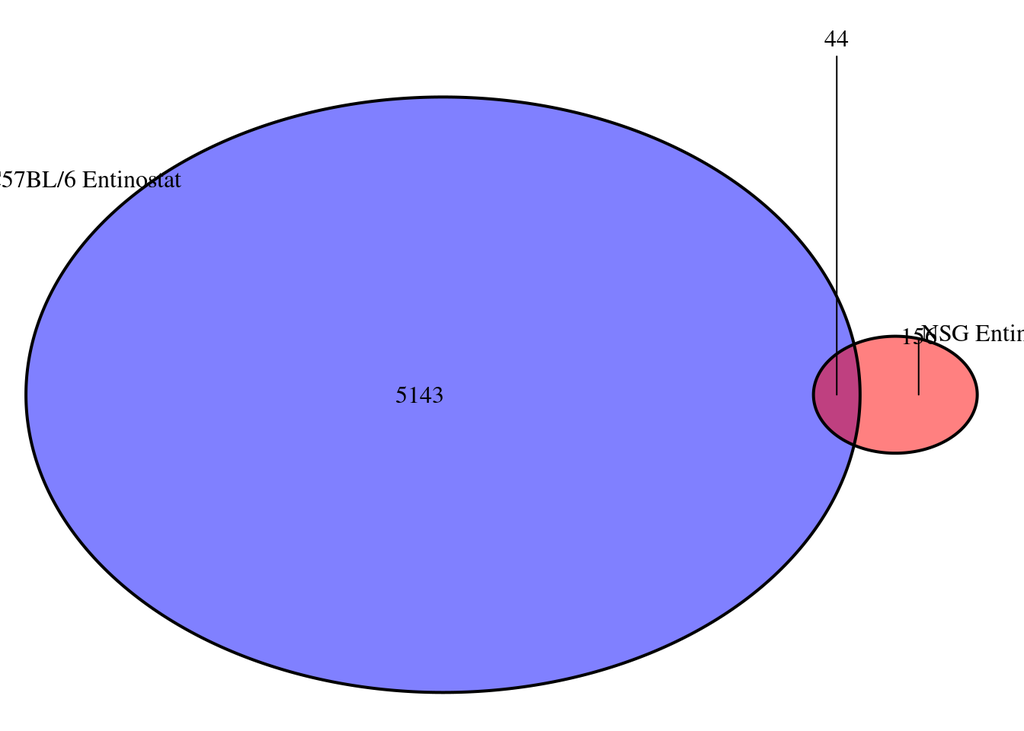

```r
# Up genen voor C57 en NSG
venn.plot_up_C57vsNSG_entinostat <- draw.pairwise.venn(
  area1 = length(up_ent_C57),
  area2 = length(up_ent_NSG),
  cross.area = length(intersect(up_ent_C57, up_ent_NSG)),
  category = c("C57BL/6 Entinostat", "NSG Entinostat"),
  fill = c("blue", "red")
)
```

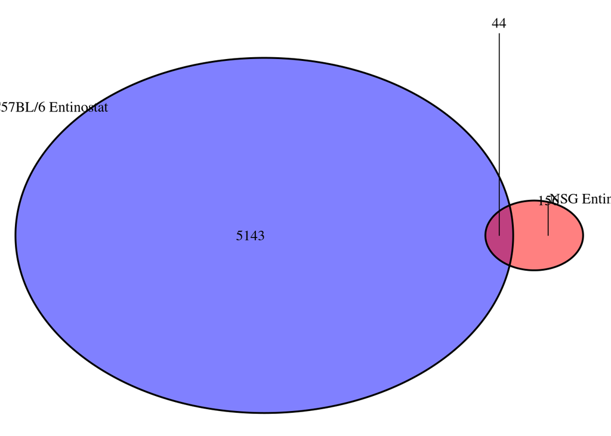

```r
grid.newpage()
grid.draw(venn.plot_up_C57vsNSG_entinostat)
```

Je ziet in plot dat er bij de entinostat de C57BL/6 (5143) aanzienlijk meer genen geactiveerd worden dan bij de NSG(156) muis. Hierbij komen 44 genen overeen.

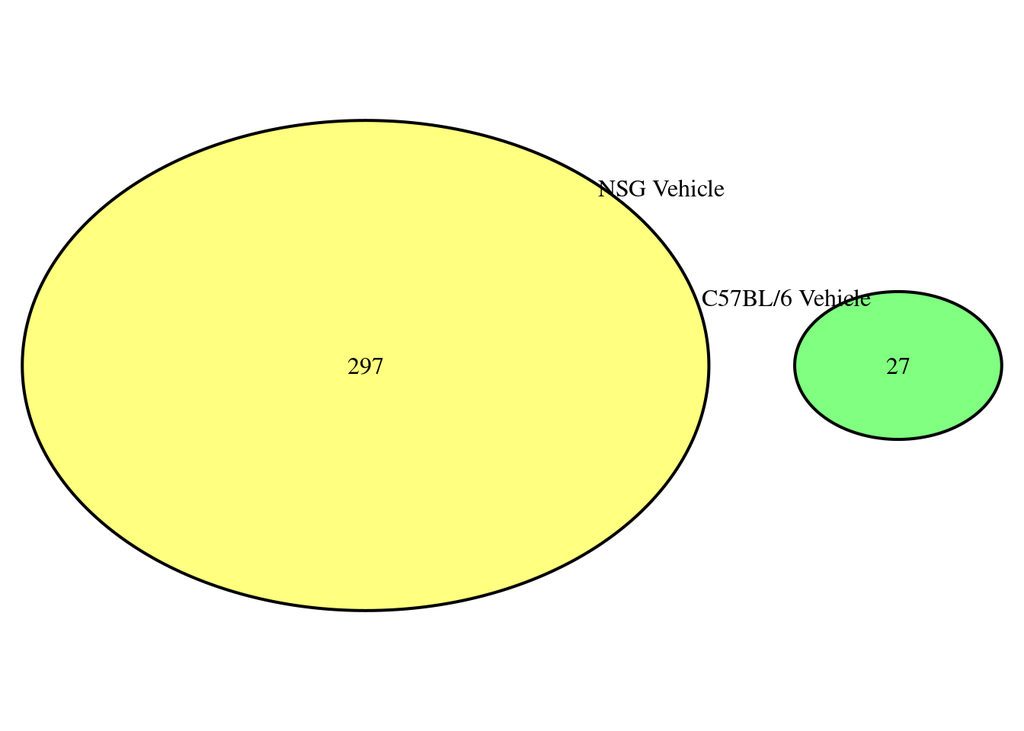

```r
# vehicle vergelijking
venn.plot_up_C57vsNSG_vehicle <- draw.pairwise.venn(
  area1 = length(up_veh_C57),
  area2 = length(up_veh_NSG),
  cross.area = length(intersect(up_veh_C57, up_veh_NSG)),
  category = c("C57BL/6 Vehicle", "NSG Vehicle"),
  fill = c("green", "yellow") # andere kleurtjes :)
)
```

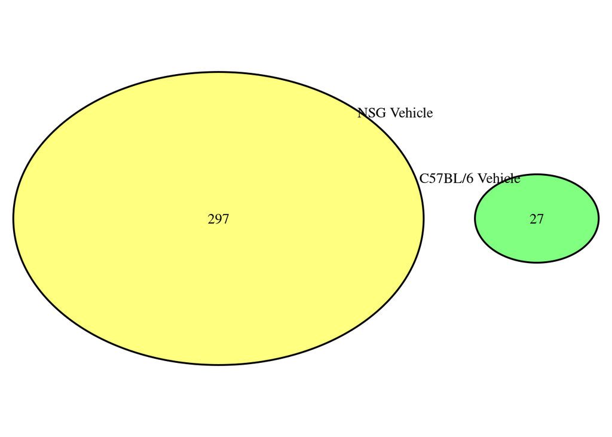

```r
grid.newpage()
grid.draw(venn.plot_up_C57vsNSG_vehicle)
```

Je ziet in plot dat er ook bij de vehicle in de NSG (297) aanzienlijk meer genen geactiveerd worden dan bij de C57BL/6 (27) muis. Hierbij komen geen genen overeen. Dit is precies andersom dan bij de entinostat; daar waren de NSG up regelated genen juist minder dan in de C57BL/6.

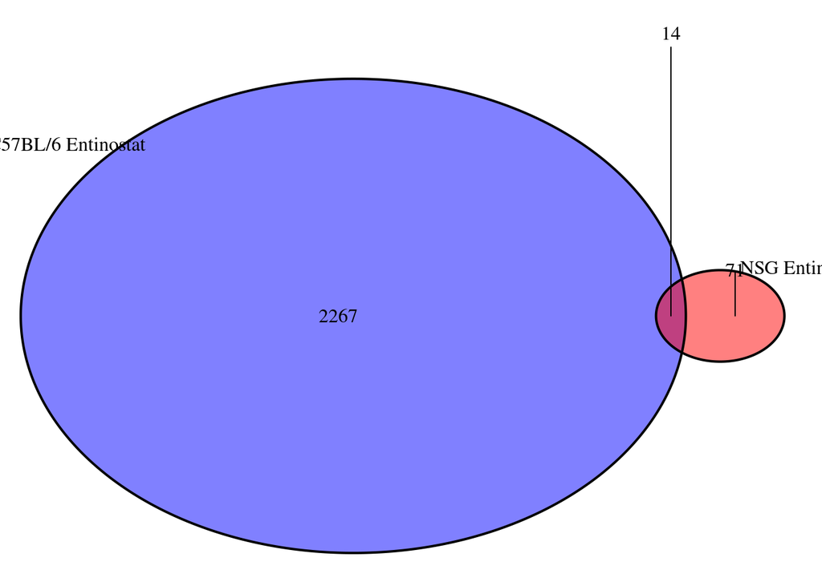

```r
# down genen voor C57 en NSG
venn.plot_down_C57vsNSG_entinostat <- draw.pairwise.venn(
  area1 = length(down_ent_C57),
  area2 = length(down_ent_NSG),
  cross.area = length(intersect(down_ent_C57, down_ent_NSG)),
  category = c("C57BL/6 Entinostat", "NSG Entinostat"),
  fill = c("blue", "red")
)
```

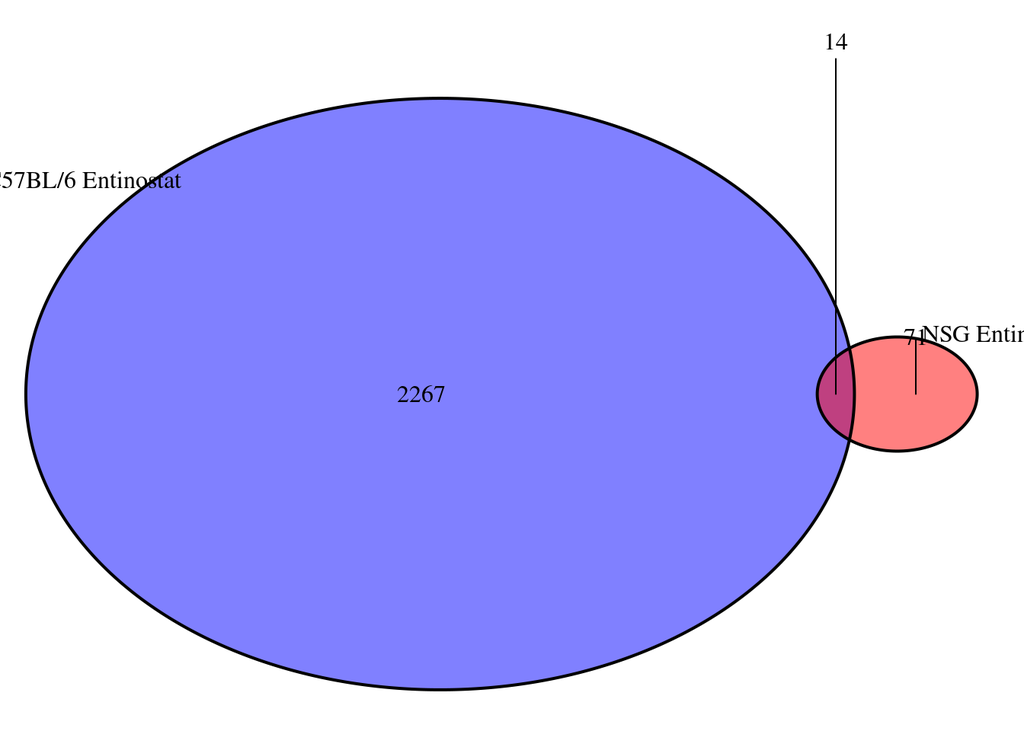

```r
grid.newpage()
grid.draw(venn.plot_down_C57vsNSG_entinostat)
```

Je ziet in plot dat er bij de entinostat de C57BL/6 (2267) aanzienlijk meer genen gedeactiveerd worden dan bij de NSG(71) muis. Hierbij komen 14 genen overeen.

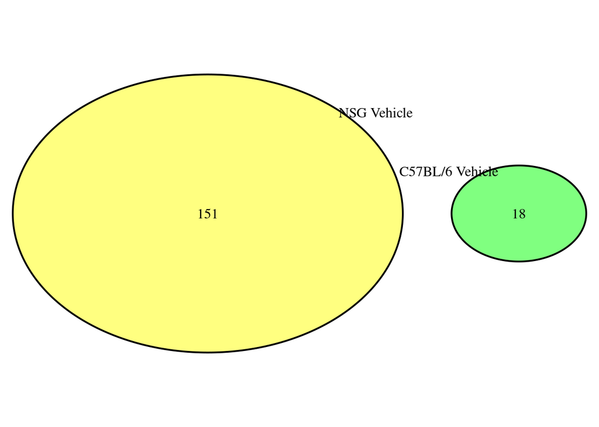

```r
venn.plot_down_C57vsNSG_vehicle <- draw.pairwise.venn(
  area1 = length(down_veh_C57),
  area2 = length(down_veh_NSG),
  cross.area = length(intersect(down_veh_C57, down_veh_NSG)),
  category = c("C57BL/6 Vehicle", "NSG Vehicle"),
  fill = c("green", "yellow")
)
```

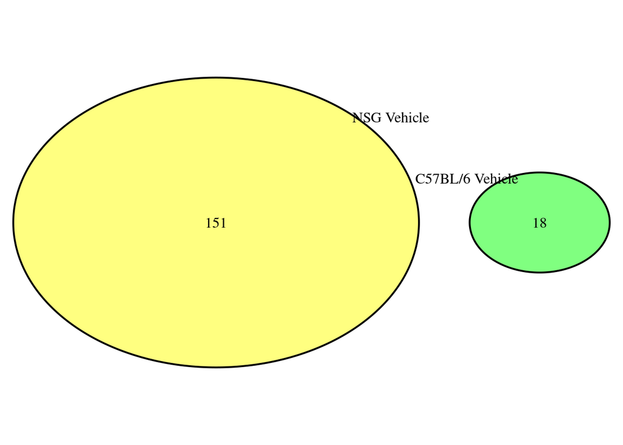

```r
grid.newpage()
grid.draw(venn.plot_down_C57vsNSG_vehicle)
```

Je ziet in plot dat er bij de vehicle de NSG (151) aanzienlijk meer genen gedeactiveerd worden dan bij de C57BL/6 (18) muis. Hierbij komen geen genen overeen. dit is net zoals bij de up regulated genen weer andersom als de enitnostat.

Nu gaan we venn diagrams maken met het verschil tussen entinostat en vehicle in beide soorten (de treatments): - Entinostat vs Vehicle binnen C57, up - Entinostat vs Vehicle binnen C57, down - Entinostat vs Vehicle binnen NSG, up  
- Entinostat vs Vehicle binnen NSG, down

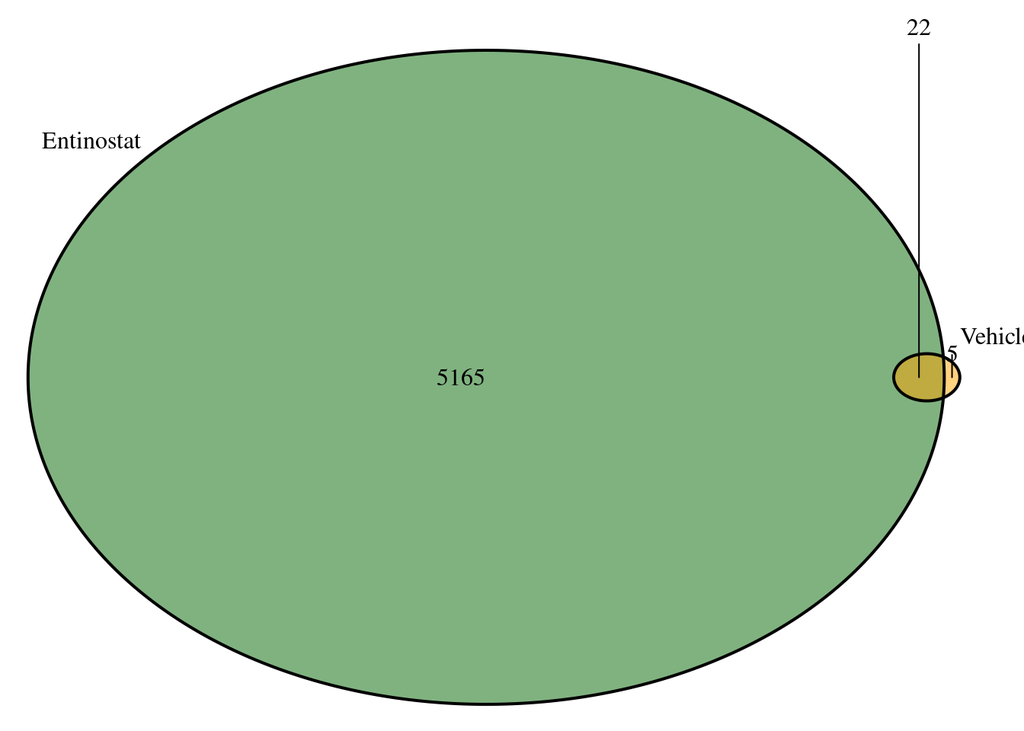

```r
# Entinostat vs Vehicle binnen C57, up
plot_up_C57_treatment <- draw.pairwise.venn(
  area1 = length(up_ent_C57),
  area2 = length(up_veh_C57),
  cross.area = length(intersect(up_ent_C57, up_veh_C57)),
  category = c("Entinostat", "Vehicle"),
  fill = c("darkgreen", "orange") # weer andere kleurtjes
)
```

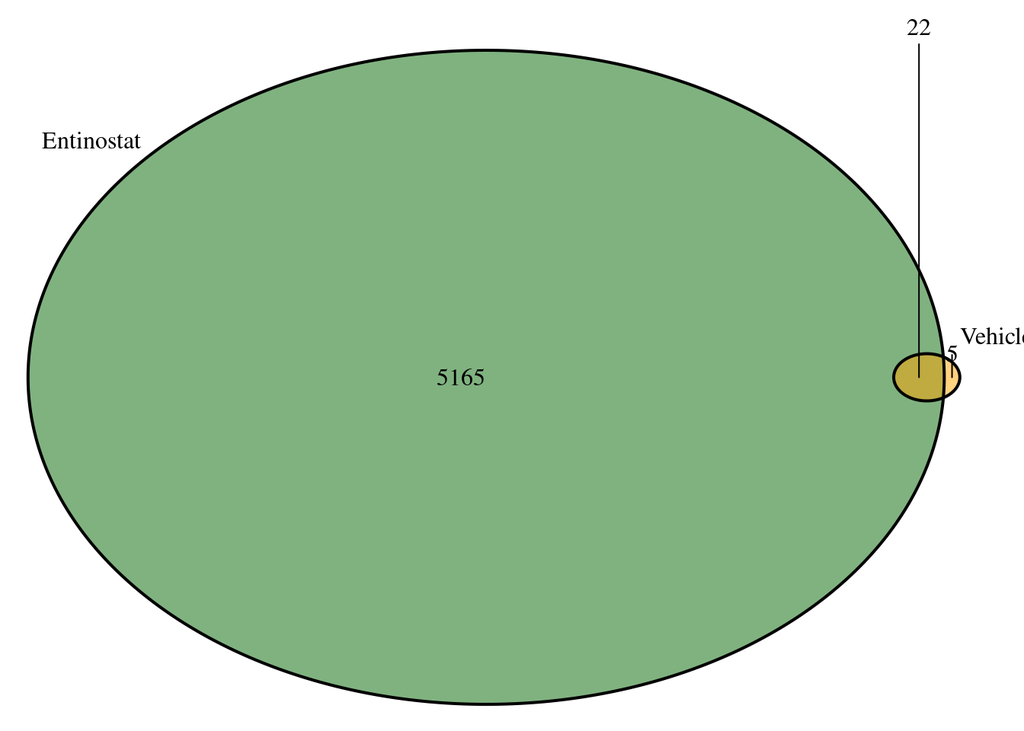

```r
grid.newpage()
grid.draw(plot_up_C57_treatment) # moet hier zonder venn.
```

Je ziet in de plot dat in de C57BL/6 er aanzienlijk meer genen up regulated zijn bij entinostat (5165) dan bij vehicle (5). Verder komen er 22 genen overeen.

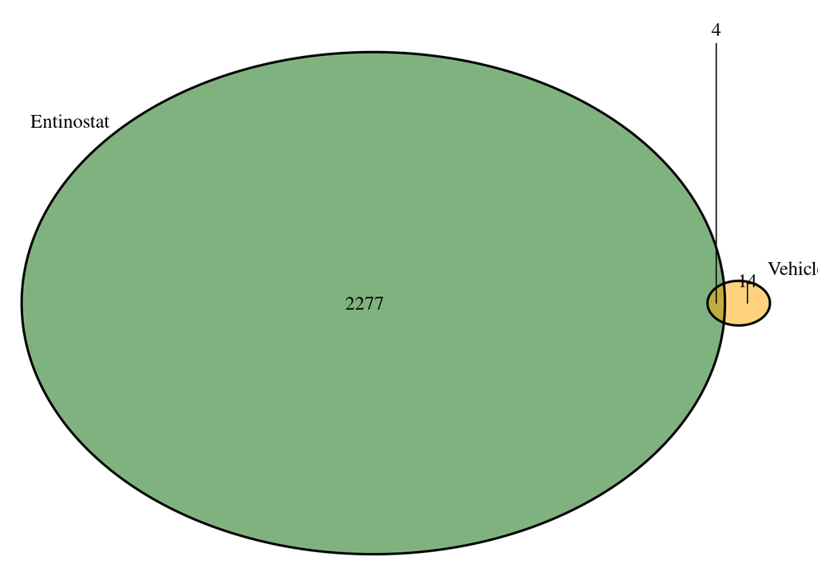

```r
# Entinostat vs Vehicle binnen C57, down
plot_down_C57_treatment <- draw.pairwise.venn(
  area1 = length(down_ent_C57),
  area2 = length(down_veh_C57),
  cross.area = length(intersect(down_ent_C57, down_veh_C57)),
  category = c("Entinostat", "Vehicle"),
  fill = c("darkgreen", "orange")
)
```

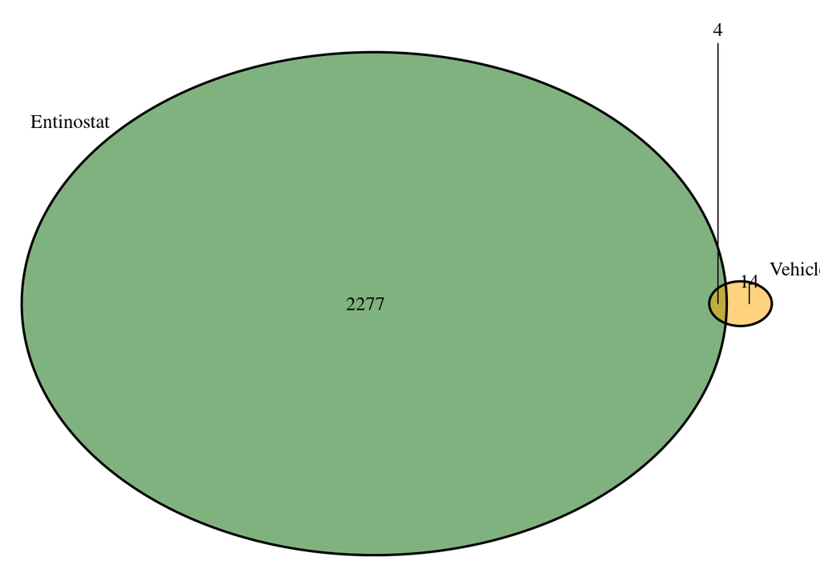

```r
grid.newpage()
grid.draw(plot_down_C57_treatment) # moet hier zonder venn.
```

Je ziet in de plot dat in de C57BL/6 er aanzienlijk meer genen down regulated zijn bij entinostat (2277) dan bij vehicle (14). Verder komen er 4 genen overeen.

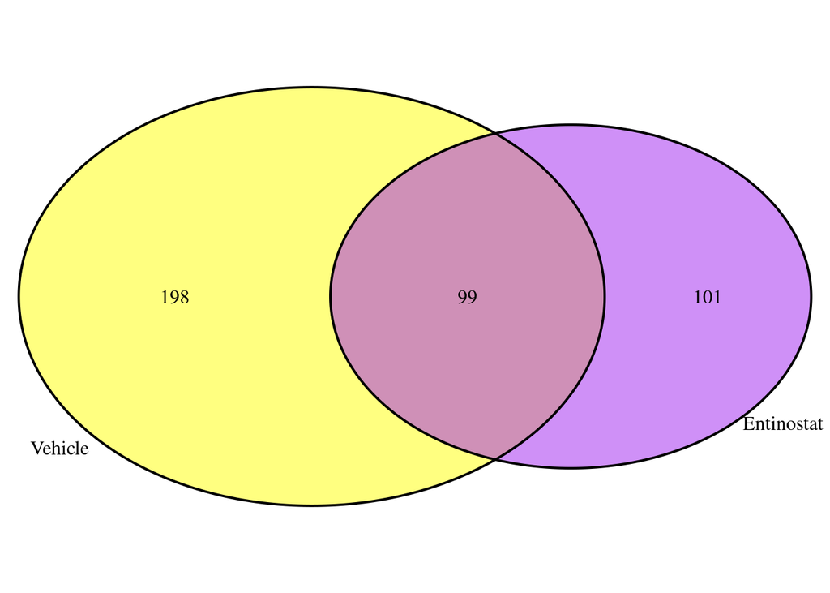

```r
# Entinostat vs Vehicle binnen NSG, up
plot_up_NSG_treatment <- draw.pairwise.venn(
  area1 = length(up_ent_NSG),
  area2 = length(up_veh_NSG),
  cross.area = length(intersect(up_ent_NSG, up_veh_NSG)),
  category = c("Entinostat", "Vehicle"),
  fill = c("purple", "yellow") # weer andere kleurtjes
)
```

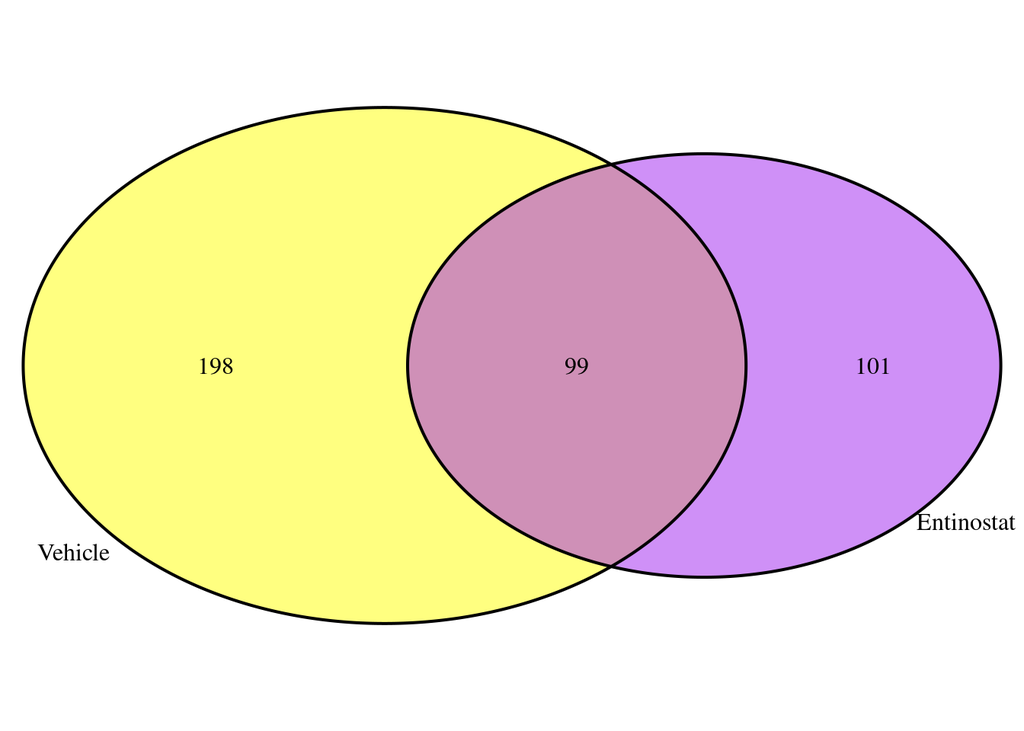

```r
grid.newpage()
grid.draw(plot_up_NSG_treatment) # moet hier zonder venn.
```

Je ziet in de plot dat in de NSG er meer genen up regulated zijn bij vehicle (198) dan bij entinostat (101). Verder komen er 99 genen overeen.

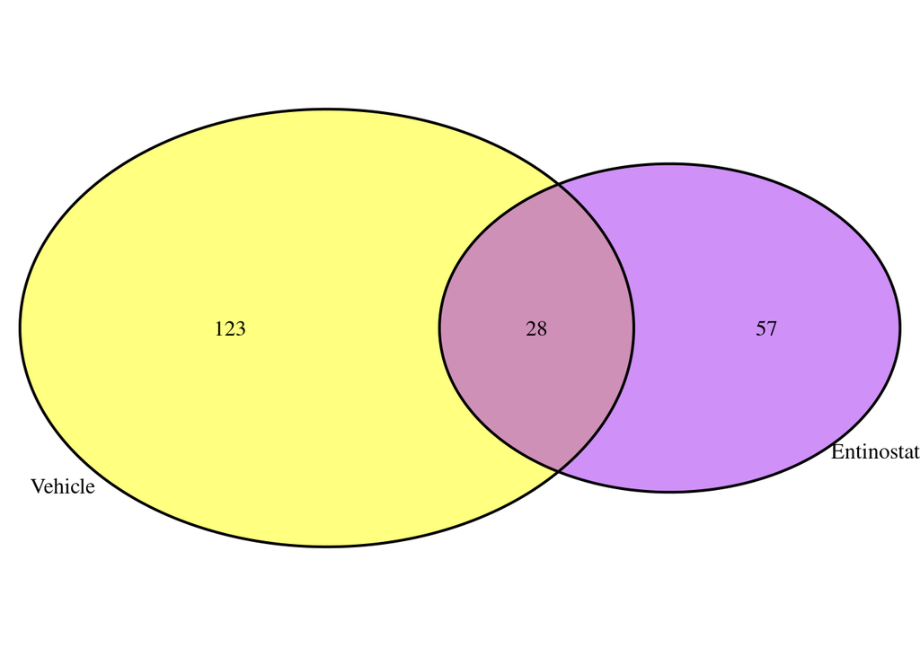

```r
# Entinostat vs Vehicle binnen NSG, down
plot_down_NSG_treatment <- draw.pairwise.venn(
  area1 = length(down_ent_NSG),
  area2 = length(down_veh_NSG),
  cross.area = length(intersect(down_ent_NSG, down_veh_NSG)),
  category = c("Entinostat", "Vehicle"),
  fill = c("purple", "yellow")
)
```

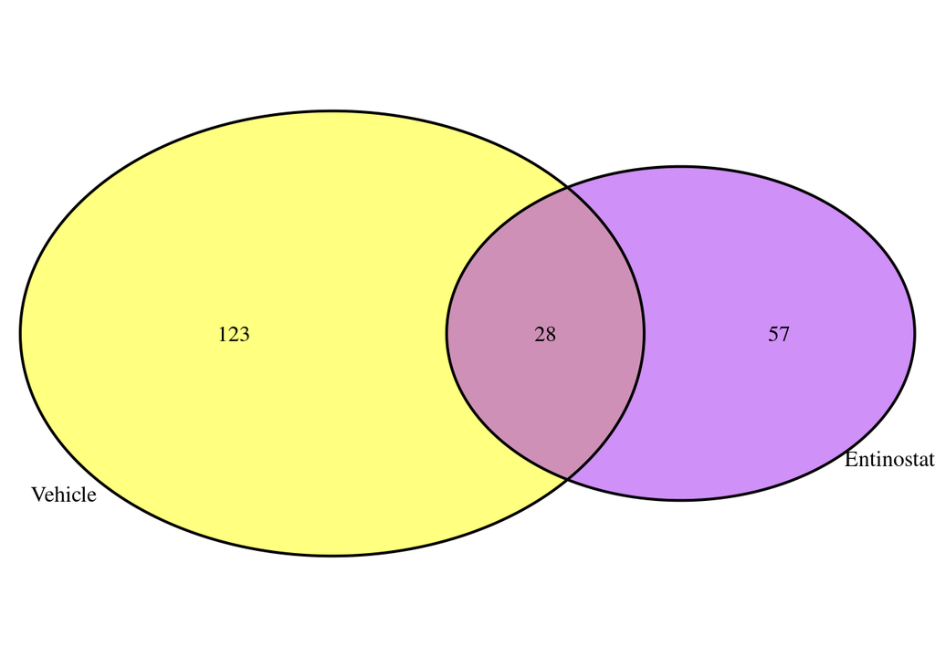

```r
grid.newpage()
grid.draw(plot_down_NSG_treatment) # moet hier zonder venn.
```

### Conclusie:

Entinostat zorgt dus voor meer gen-veranderingen in C57 dan in NSG muizen. Dit geldt voor up en down regulated genen. Dus zal entinostat een redelijk werkend immuunsysteem moeten hebben (wat NSG muizen niet hebben en C57 muizen wel).